# [EM1413] - Health Data Science

Alessia Pizzolla 891453 - Matteo Valenti 879393

2025-07-16

## Inspecting the relationship between psychological health and tumor

## Problem Definition

In this project, we aim to explore the potential association between psychological health and the development of physical illnesses. In particular, we focused on cancer, investigating whether certain patterns in mental health could be linked to an increased risk of developing tumors.

## Abstract

This study investigates the complex relationship between psychological well-being and the onset of physical illnesses, with a particular focus on cancer. The primary aim is to explore whether specific patterns of mental health distress are associated with an increased risk of tumor development.

To address this, we conducted an exploratory data analysis and employed contingency tables to identify preliminary associations between psychological and physical health indicators. Statistical models—including logistic regression, generalized linear mixed models (GLMM), Poisson and binomial regressions—were applied to quantify risk and control for potential confounding variables.

Furthermore, we examined the reverse relationship, assessing how psychological health may be influenced by physical conditions and socio-demographic factors, using ordered regression models.

The findings suggest a bidirectional link between mental and physical health, highlighting the importance of integrated approaches in both the prevention and treatment of oncological diseases.

## Installing and loading of the necessary packages

In this section, we upload and prepare the 2023 PASSI dataset (Progressi delle Aziende Sanitarie per la Salute in Italia). PASSI is a continuous public health surveillance system, inspired by the Behavioural Risk Factor Surveillance model used in many countries. Since 2008, it has collected data on lifestyle and behavioural risk factors linked to chronic non-communicable diseases in Italian adults aged 18–69, as well as on awareness and participation in prevention programs.

Coordinated by the Istituto Superiore di Sanità, PASSI is a key tool for the Italian National Health System. It provides timely and ongoing data at both the regional and local health unit (LHU) levels, supporting the design and evaluation of preventive health policies in line with national and regional prevention plans.

I have loaded the cleaned Excel file, selecting only the specified columns (`id`, `regione`, `sesso_intervistato`, `data_intervista`, `s01_salute_psic`, `s01_tumori`, s02_attiv_30_gg_quanto`,`s03_fumo`,`s03_fumo_att`,`s04_consu_frutta`,`s05_alcool_gg`,`s07_eta`,`s12_poco_inter_gg`,`s14_stato_civ`,`s14_tit_stud`,`s14_disp_econ`,`s01_malattie_croniche`,`s01_insuff_renale`,`s01_bronchite`,`s01_asma_bronchiale`,`s14_cittadin`,`s18_qualita_aria`,`s09_mammo_eseg`,`s10_so_eseg`,`s14_codifica_mansione`,`imc4cat`,`s01_tum_anni_diagnosi`)

```
## tibble [31,556 × 27] (S3: tbl_df/tbl/data.frame)
##  $ id                    : num [1:31556] 4365891 4272946 4411436 4283197 4295931 ...
##  $ regione               : num [1:31556] 200 60 10 10 110 180 10 160 190 160 ...
##  $ sesso_intervistato    : chr [1:31556] "M" "M" "M" "M" ...
##  $ data_intervista       : chr [1:31556] "2023-09-22" "2023-04-03" "2023-12-19" "2023-04-12" ...
##  $ s01_salute_psic       : num [1:31556] 0 0 0 0 0 0 30 0 0 -99 ...
##  $ s01_tumori            : chr [1:31556] "f" "f" "t" "f" ...
##  $ s02_attiv_30_gg_quanto: num [1:31556] 1 3 3 2 4 2 2 2 4 3 ...
##  $ s03_fumo              : num [1:31556] 1 2 1 2 1 2 2 2 2 -99 ...
##  $ s03_fumo_att          : chr [1:31556] "f" NA "f" NA ...
##  $ s04_consu_frutta      : num [1:31556] 4 2 4 2 2 3 2 2 3 3 ...
##  $ s05_alcool_gg         : num [1:31556] 20 0 0 0 8 10 20 2 0 -99 ...
##  $ s07_eta               : num [1:31556] 61 58 47 19 53 33 66 29 23 66 ...
##  $ s12_poco_inter_gg     : num [1:31556] 0 0 0 0 0 0 14 0 0 -99 ...
##  $ s14_stato_civ         : num [1:31556] 1 1 2 2 1 1 1 2 2 1 ...
##  $ s14_tit_stud          : num [1:31556] 4 5 4 3 4 4 4 5 5 3 ...
##  $ s14_disp_econ         : num [1:31556] 2 2 2 2 2 2 1 3 2 3 ...
##  $ s01_malattie_croniche : chr [1:31556] "f" "f" "f" "f" ...
##  $ s01_insuff_renale     : chr [1:31556] "f" "f" "f" "f" ...
##  $ s01_bronchite         : chr [1:31556] "f" "f" "f" "f" ...
##  $ s01_asma_bronchiale   : chr [1:31556] "f" "f" "f" "f" ...
##  $ s14_cittadin          : num [1:31556] 1 1 1 1 1 1 1 1 1 1 ...
##  $ s18_qualita_aria      : num [1:31556] 3 2 NA NA 2 NA NA NA 3 NA ...
##  $ s09_mammo_eseg        : num [1:31556] NA NA NA NA NA NA 1 NA NA 2 ...
##  $ s10_so_eseg           : num [1:31556] 1 1 NA NA 2 NA 2 NA NA 2 ...
##  $ s14_codifica_mansione : num [1:31556] NA 1 6 NA 9 NA NA 5 NA NA ...
##  $ imc4cat               : chr [1:31556] "2 Normopeso" "3 Sovrappeso" "2 Normopeso" "2 Normopeso" ...
##  $ s01_tum_anni_diagnosi : num [1:31556] NA NA 13 NA NA NA NA NA NA NA ...
```

We define a vector called ‘factor_variable’ that contains the names of the variables in the dataset which will be treated as categorical (factors). These include demographic variables (e.g., region, gender), health conditions (e.g., tumors, chronic diseases), behaviors (e.g., smoking, physical activity, diet), socioeconomic indicators (e.g., education, economic conditions), and preventive actions (e.g., screening participation).

## Pre - Processing

```
## tibble [31,556 × 27] (S3: tbl_df/tbl/data.frame)
##  $ id                    : num [1:31556] 4365891 4272946 4411436 4283197 4295931 ...
##  $ regione               : Factor w/ 20 levels "10","20","41",..: 20 6 1 1 11 18 1 16 19 16 ...
##  $ sesso_intervistato    : Factor w/ 2 levels "F","M": 2 2 2 2 2 1 1 1 1 1 ...
##  $ data_intervista       : chr [1:31556] "2023-09-22" "2023-04-03" "2023-12-19" "2023-04-12" ...
##  $ s01_salute_psic       : num [1:31556] 0 0 0 0 0 0 30 0 0 -99 ...
##  $ s01_tumori            : Factor w/ 2 levels "0","1": 1 1 2 1 1 1 1 1 1 1 ...
##  $ s02_attiv_30_gg_quanto: Factor w/ 5 levels "-99","1","2",..: 2 4 4 3 5 3 3 3 5 4 ...
##  $ s03_fumo              : Factor w/ 3 levels "-99","1","2": 2 3 2 3 2 3 3 3 3 1 ...
##  $ s03_fumo_att          : Factor w/ 2 levels "0","1": 1 NA 1 NA 1 NA NA NA NA NA ...
##  $ s04_consu_frutta      : Factor w/ 4 levels "1","2","3","4": 4 2 4 2 2 3 2 2 3 3 ...
##  $ s05_alcool_gg         : num [1:31556] 20 0 0 0 8 10 20 2 0 -99 ...
##  $ s07_eta               : num [1:31556] 61 58 47 19 53 33 66 29 23 66 ...
##  $ s12_poco_inter_gg     : num [1:31556] 0 0 0 0 0 0 14 0 0 -99 ...
##  $ s14_stato_civ         : Factor w/ 4 levels "1","2","3","4": 1 1 2 2 1 1 1 2 2 1 ...
##  $ s14_tit_stud          : Factor w/ 5 levels "1","2","3","4",..: 4 5 4 3 4 4 4 5 5 3 ...
##  $ s14_disp_econ         : Factor w/ 4 levels "1","2","3","4": 2 2 2 2 2 2 1 3 2 3 ...
##  $ s01_malattie_croniche : Factor w/ 2 levels "0","1": 1 1 1 1 1 1 1 1 1 1 ...
##  $ s01_insuff_renale     : Factor w/ 2 levels "0","1": 1 1 1 1 1 1 1 1 1 1 ...
##  $ s01_bronchite         : Factor w/ 2 levels "0","1": 1 1 1 1 1 1 1 1 1 1 ...
##  $ s01_asma_bronchiale   : Factor w/ 2 levels "0","1": 1 1 1 1 1 1 1 1 1 1 ...
##  $ s14_cittadin          : Factor w/ 3 levels "1","2","3": 1 1 1 1 1 1 1 1 1 1 ...
##  $ s18_qualita_aria      : Factor w/ 5 levels "-99","1","2",..: 4 3 NA NA 3 NA NA NA 4 NA ...
##  $ s09_mammo_eseg        : Factor w/ 3 levels "-99","1","2": NA NA NA NA NA NA 2 NA NA 3 ...
##  $ s10_so_eseg           : Factor w/ 3 levels "-99","1","2": 2 2 NA NA 3 NA 3 NA NA 3 ...
##  $ s14_codifica_mansione : Factor w/ 10 levels "0","1","2","3",..: 1 2 7 1 10 1 1 6 1 1 ...
##  $ imc4cat               : Factor w/ 4 levels "1 Sottopeso",..: 2 3 2 2 2 2 1 2 3 NA ...
##  $ s01_tum_anni_diagnosi : num [1:31556] NA NA 13 NA NA NA NA NA NA NA ...
```

```
## Rows: 31,556
## Columns: 27
## $ id                     <dbl> 4365891, 4272946, 4411436, 4283197, 4295931, 42…
## $ regione                <fct> Sardegna, Friuli Venezia Giulia, Piemonte, Piem…
## $ sesso_intervistato     <fct> M, M, M, M, M, F, F, F, F, F, M, F, M, M, M, M,…
## $ data_intervista        <chr> "2023-09-22", "2023-04-03", "2023-12-19", "2023…
## $ s01_salute_psic        <dbl> 0, 0, 0, 0, 0, 0, 30, 0, 0, -99, 0, 0, -99, 0, …
## $ s01_tumori             <fct> no, no, sì, no, no, no, no, no, no, no, no, no,…
## $ s02_attiv_30_gg_quanto <fct> buona, non suff, non suff, suff, scarsa, suff, …
## $ s03_fumo               <fct> ha fumato, non ha fumato, ha fumato, non ha fum…
## $ s03_fumo_att           <fct> 0, NA, 0, NA, 0, NA, NA, NA, NA, NA, NA, NA, 0,…
## $ s04_consu_frutta       <fct> 5, 1-2, 5, 1-2, 1-2, 3-4, 1-2, 1-2, 3-4, 3-4, 3…
## $ s05_alcool_gg          <dbl> 20, 0, 0, 0, 8, 10, 20, 2, 0, -99, 30, 0, 0, 30…
## $ s07_eta                <dbl> 61, 58, 47, 19, 53, 33, 66, 29, 23, 66, 54, 21,…
## $ s12_poco_inter_gg      <dbl> 0, 0, 0, 0, 0, 0, 14, 0, 0, -99, 4, 0, -99, 0, …
## $ s14_stato_civ          <fct> coniugato, coniugato, celibe/nubile, celibe/nub…
## $ s14_tit_stud           <fct> diploma, laurea, diploma, media, diploma, diplo…
## $ s14_disp_econ          <fct> abbastanza facilmente, abbastanza facilmente, a…
## $ s01_malattie_croniche  <fct> no, no, no, no, no, no, no, no, no, no, no, no,…
## $ s01_insuff_renale      <fct> no, no, no, no, no, no, no, no, no, no, no, no,…
## $ s01_bronchite          <fct> no, no, no, no, no, no, no, no, no, no, no, no,…
## $ s01_asma_bronchiale    <fct> no, no, no, no, no, no, no, no, no, no, no, no,…
## $ s14_cittadin           <fct> ita, ita, ita, ita, ita, ita, ita, ita, ita, it…
## $ s18_qualita_aria       <fct> cattiva, abb buona, NA, NA, abb buona, NA, NA, …
## $ s09_mammo_eseg         <fct> NA, NA, NA, NA, NA, NA, sì, NA, NA, no, NA, NA,…
## $ s10_so_eseg            <fct> sì, sì, NA, NA, no, NA, no, NA, NA, no, sì, NA,…
## $ s14_codifica_mansione  <fct> disoccupato, imprenditore/leg/dir, operaio/agri…
## $ peso                   <fct> normopeso, sovrappeso, normopeso, normopeso, no…
## $ s01_tum_anni_diagnosi  <dbl> NA, NA, 13, NA, NA, NA, NA, NA, NA, NA, NA, NA,…
```

```
## tibble [31,556 × 27] (S3: tbl_df/tbl/data.frame)
##  $ id                    : num [1:31556] 4365891 4272946 4411436 4283197 4295931 ...
##  $ regione               : Factor w/ 19 levels "Piemonte","Valle d'Aosta",..: 19 5 1 1 10 17 1 15 18 15 ...
##  $ sesso_intervistato    : Factor w/ 2 levels "F","M": 2 2 2 2 2 1 1 1 1 1 ...
##  $ data_intervista       : chr [1:31556] "2023-09-22" "2023-04-03" "2023-12-19" "2023-04-12" ...
##  $ s01_salute_psic       : num [1:31556] 0 0 0 0 0 0 30 0 0 -99 ...
##  $ s01_tumori            : Factor w/ 2 levels "no","sì": 1 1 2 1 1 1 1 1 1 1 ...
##  $ s02_attiv_30_gg_quanto: Factor w/ 5 levels "-99","buona",..: 2 4 4 3 5 3 3 3 5 4 ...
##  $ s03_fumo              : Factor w/ 3 levels "-99","ha fumato",..: 2 3 2 3 2 3 3 3 3 1 ...
##  $ s03_fumo_att          : Factor w/ 3 levels "-99","non fuma",..: 2 1 2 1 2 1 1 1 1 NA ...
##  $ s04_consu_frutta      : Factor w/ 4 levels "0","1-2","3-4",..: 4 2 4 2 2 3 2 2 3 3 ...
##  $ s05_alcool_gg         : num [1:31556] 20 0 0 0 8 10 20 2 0 -99 ...
##  $ s07_eta               : num [1:31556] 61 58 47 19 53 33 66 29 23 66 ...
##  $ s12_poco_inter_gg     : num [1:31556] 0 0 0 0 0 0 14 0 0 -99 ...
##  $ s14_stato_civ         : Factor w/ 4 levels "coniugato","celibe/nubile",..: 1 1 2 2 1 1 1 2 2 1 ...
##  $ s14_tit_stud          : Factor w/ 5 levels "no titolo","elementare",..: 4 5 4 3 4 4 4 5 5 3 ...
##  $ s14_disp_econ         : Factor w/ 4 levels "molto facilmente",..: 2 2 2 2 2 2 1 3 2 3 ...
##  $ s01_malattie_croniche : Factor w/ 2 levels "no","sì": 1 1 1 1 1 1 1 1 1 1 ...
##  $ s01_insuff_renale     : Factor w/ 2 levels "no","sì": 1 1 1 1 1 1 1 1 1 1 ...
##  $ s01_bronchite         : Factor w/ 2 levels "no","sì": 1 1 1 1 1 1 1 1 1 1 ...
##  $ s01_asma_bronchiale   : Factor w/ 2 levels "no","sì": 1 1 1 1 1 1 1 1 1 1 ...
##  $ s14_cittadin          : Factor w/ 3 levels "ita","straniera",..: 1 1 1 1 1 1 1 1 1 1 ...
##  $ s18_qualita_aria      : Factor w/ 5 levels "-99","molto buona",..: 4 3 NA NA 3 NA NA NA 4 NA ...
##  $ s09_mammo_eseg        : Factor w/ 3 levels "-99","sì","no": NA NA NA NA NA NA 2 NA NA 3 ...
##  $ s10_so_eseg           : Factor w/ 3 levels "-99","sì","no": 2 2 NA NA 3 NA 3 NA NA 3 ...
##  $ s14_codifica_mansione : Factor w/ 10 levels "disoccupato",..: 1 2 7 1 10 1 1 6 1 1 ...
##  $ peso                  : Factor w/ 4 levels "sottopeso","normopeso",..: 2 3 2 2 2 2 1 2 3 NA ...
##  $ s01_tum_anni_diagnosi : num [1:31556] -99 -99 13 -99 -99 -99 -99 -99 -99 -99 ...
```

We filtered the dataset to remove rows with invalid or placeholder values: - For ‘s03_fumo’ (smoking status), we kept only “ha fumato” (has smoked) and “non ha fumato” (has not smoked), then removed unused factor levels. - For ‘s02_attiv_30_gg_quanto’ (physical activity in the last 30 days), we kept only the valid responses (“buona”, “suff”, “non suff”, “scarsa”) and dropped unused factor levels.

Data summary

| Name | ps |
| --- | --- |
| Number of rows | 30637 |
| Number of columns | 29 |
| _______________________ |  |
| Column type frequency: |  |
| character | 1 |
| factor | 21 |
| numeric | 7 |
| ________________________ |  |
| Group variables | None |

**Variable type: character**

| skim_variable | n_missing | complete_rate | min | max | empty | n_unique | whitespace |
| --- | --- | --- | --- | --- | --- | --- | --- |
| data_intervista | 0 | 1 | 10 | 10 | 0 | 357 | 0 |

**Variable type: factor**

| skim_variable | n_missing | complete_rate | ordered | n_unique | top_counts |
| --- | --- | --- | --- | --- | --- |
| regione | 0 | 1.00 | FALSE | 19 | Tos: 3364, Pie: 3193, Emi: 2930, Laz: 2899 |
| sesso_intervistato | 0 | 1.00 | FALSE | 2 | F: 15810, M: 14827 |
| s01_tumori | 0 | 1.00 | FALSE | 2 | no: 29291, sì: 1346 |
| s02_attiv_30_gg_quanto | 0 | 1.00 | FALSE | 4 | suf: 11619, non: 8798, sca: 6333, buo: 3887 |
| s03_fumo | 0 | 1.00 | FALSE | 2 | non: 17841, ha : 12796 |
| s03_fumo_att | 0 | 1.00 | FALSE | 3 | -99: 17841, fum: 7044, non: 5752 |
| s04_consu_frutta | 0 | 1.00 | FALSE | 4 | 1-2: 15654, 3-4: 12084, 5: 2104, 0: 795 |
| s14_stato_civ | 0 | 1.00 | FALSE | 4 | con: 16224, cel: 11547, sep: 2257, ved: 609 |
| s14_tit_stud | 0 | 1.00 | FALSE | 5 | dip: 15591, med: 7410, lau: 6919, ele: 621 |
| s14_disp_econ | 0 | 1.00 | FALSE | 4 | abb: 15790, qua: 9750, mol: 3402, mol: 1695 |
| s01_malattie_croniche | 0 | 1.00 | FALSE | 2 | no: 30310, sì: 327 |
| s01_insuff_renale | 0 | 1.00 | FALSE | 2 | no: 30363, sì: 274 |
| s01_bronchite | 0 | 1.00 | FALSE | 2 | no: 29893, sì: 744 |
| s01_asma_bronchiale | 0 | 1.00 | FALSE | 2 | no: 29368, sì: 1269 |
| s14_cittadin | 0 | 1.00 | FALSE | 3 | ita: 28361, str: 1797, dop: 479 |
| s18_qualita_aria | 13413 | 0.56 | FALSE | 5 | abb: 10639, mol: 4176, cat: 1849, -99: 348 |
| s09_mammo_eseg | 20111 | 0.34 | FALSE | 3 | sì: 8805, no: 1677, -99: 44 |
| s10_so_eseg | 16824 | 0.45 | FALSE | 3 | sì: 7672, no: 6002, -99: 139 |
| s14_codifica_mansione | 0 | 1.00 | FALSE | 10 | dis: 10195, ese: 4201, com: 3407, int: 3238 |
| peso | 0 | 1.00 | FALSE | 4 | nor: 16817, sov: 9744, obe: 3132, sot: 944 |
| chronic | 0 | 1.00 | FALSE | 2 | no: 28356, sì: 2281 |

**Variable type: numeric**

| skim_variable | n_missing | complete_rate | mean | sd | p0 | p25 | p50 | p75 | p100 | hist |
| --- | --- | --- | --- | --- | --- | --- | --- | --- | --- | --- |
| id | 0 | 1 | 4337341.27 | 54997.04 | 4229291 | 4289079 | 4337183 | 4387809 | 4458200 | ▅▇▆▇▂ |
| s01_salute_psic | 0 | 1 | 0.56 | 16.04 | -99 | 0 | 0 | 2 | 30 | ▁▁▁▇▂ |
| s05_alcool_gg | 0 | 1 | 3.98 | 17.11 | -99 | 0 | 2 | 7 | 30 | ▁▁▁▇▅ |
| s07_eta | 0 | 1 | 45.88 | 14.32 | 18 | 34 | 48 | 58 | 69 | ▅▆▇▇▇ |
| s12_poco_inter_gg | 0 | 1 | -2.15 | 17.56 | -99 | 0 | 0 | 0 | 14 | ▁▁▁▁▇ |
| s01_tum_anni_diagnosi | 0 | 1 | -94.42 | 24.68 | -99 | -99 | -99 | -99 | 2016 | ▇▁▁▁▁ |
| count.1 | 0 | 1 | 0.09 | 0.32 | 0 | 0 | 0 | 0 | 4 | ▇▁▁▁▁ |

We want to treat the variable ‘s01_salute_psic’ (psychological health) as an ordinal categorical variable.

We are creating a histogram showing the distribution of the number of days in the month in which individuals reported feeling mentally unwell (variable: s01_salute_psic). The x-axis represents the number of days, and the y-axis shows the frequency of respondents for each value.

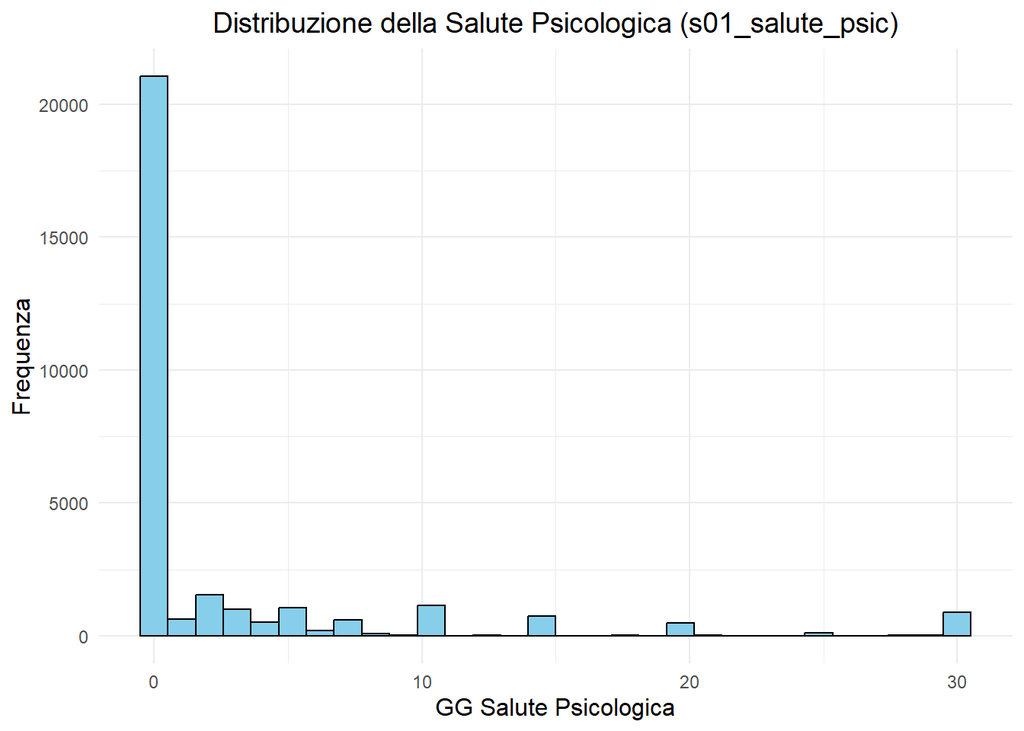

Since a large number of respondents reported 0 days of psychological distress (i.e., they never felt mentally unwell), and there is a spread across the other values, we decided to group the variable into four categories: 0 = “bene”, 1–9 = “abb bene”, 10–19 = “male”, 20–30 = “molto male”. This choice was made to reflect the fact that many individuals report feeling very well.

```
## tibble [29,980 × 30] (S3: tbl_df/tbl/data.frame)
##  $ id                    : num [1:29980] 4365891 4272946 4411436 4283197 4295931 ...
##  $ regione               : Factor w/ 19 levels "Piemonte","Valle d'Aosta",..: 19 5 1 1 10 17 1 15 18 8 ...
##  $ sesso_intervistato    : Factor w/ 2 levels "F","M": 2 2 2 2 2 1 1 1 1 2 ...
##  $ data_intervista       : chr [1:29980] "2023-09-22" "2023-04-03" "2023-12-19" "2023-04-12" ...
##  $ s01_salute_psic       : num [1:29980] 0 0 0 0 0 0 30 0 0 0 ...
##  $ s01_tumori            : Factor w/ 2 levels "no","sì": 1 1 2 1 1 1 1 1 1 1 ...
##  $ s02_attiv_30_gg_quanto: Factor w/ 4 levels "buona","suff",..: 1 3 3 2 4 2 2 2 4 3 ...
##  $ s03_fumo              : Factor w/ 2 levels "ha fumato","non ha fumato": 1 2 1 2 1 2 2 2 2 2 ...
##  $ s03_fumo_att          : Factor w/ 3 levels "-99","non fuma",..: 2 1 2 1 2 1 1 1 1 1 ...
##  $ s04_consu_frutta      : Factor w/ 4 levels "0","1-2","3-4",..: 4 2 4 2 2 3 2 2 3 3 ...
##  $ s05_alcool_gg         : num [1:29980] 20 0 0 0 8 10 20 2 0 30 ...
##  $ s07_eta               : num [1:29980] 61 58 47 19 53 33 66 29 23 54 ...
##  $ s12_poco_inter_gg     : num [1:29980] 0 0 0 0 0 0 14 0 0 4 ...
##  $ s14_stato_civ         : Factor w/ 4 levels "coniugato","celibe/nubile",..: 1 1 2 2 1 1 1 2 2 1 ...
```

[output cut: 16 more lines]

## Exploratory analysis

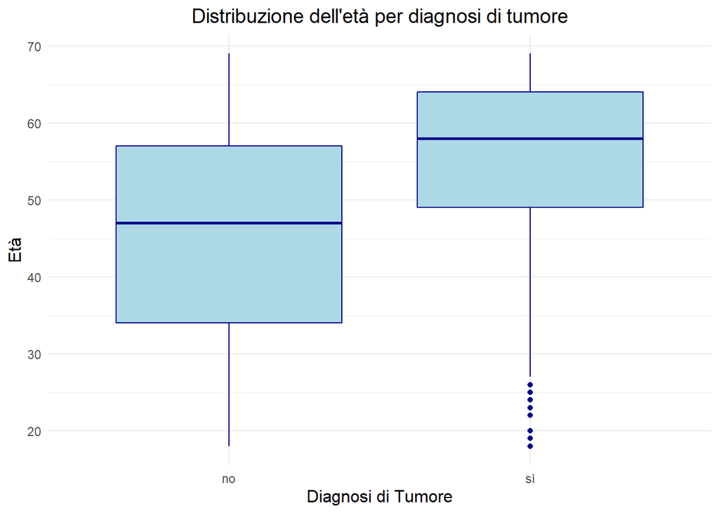

The boxplot indicates that individuals diagnosed with a tumor (“yes”) tend to be older than those without a diagnosis (“no”). The median age is higher in the “yes” group (~58 years) compared to the “no” group (~46 years). The age distribution is also more concentrated among diagnosed individuals, as shown by the smaller interquartile range. Several outliers are present in the “yes” group, representing younger patients who also received a tumor diagnosis. This suggests a general association between increasing age and the likelihood of tumor diagnosis, although younger cases do exist.

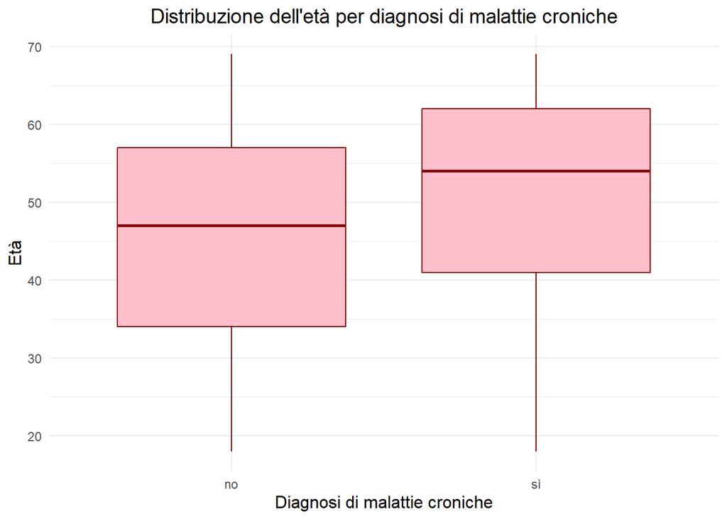

Same plot for overall chronic diseases: The boxplot illustrates the age distribution based on the diagnosis of chronic diseases. Individuals diagnosed with at least one chronic disease (“yes”) tend to be older on average, with a median age slightly above that of those without a chronic disease diagnosis (“no”). The interquartile range is similar between the two groups, although the distribution for the “yes” group is slightly more concentrated in higher age ranges. Both groups show a wide age range, indicating that chronic conditions can occur at various ages. However, the overall trend suggests a positive association between increasing age and the presence of chronic diseases.

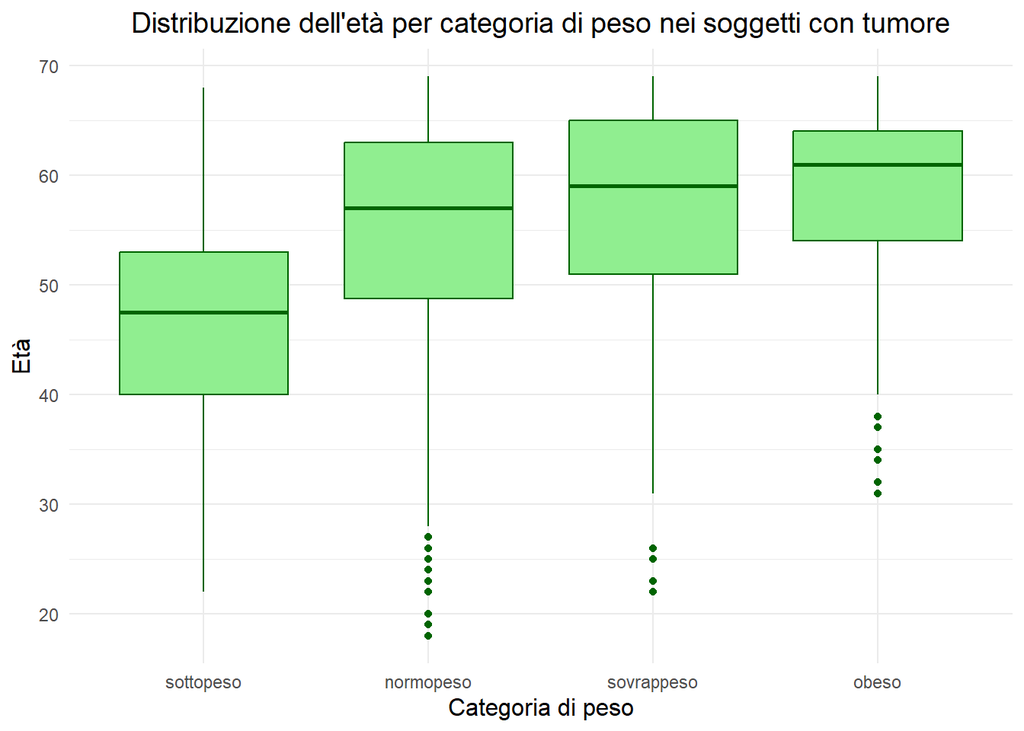

The boxplot shows the age distribution across different weight categories among individuals diagnosed with tumors. On average, underweight individuals appear to be younger than those in the other categories, while overweight and obese individuals tend to be older. The median age increases progressively from underweight to obese. There are several outliers, particularly among normal weight and overweight individuals, with lower age values. This suggests a possible association between higher age and higher BMI in tumor patients, but statistical testing would be required to confirm significance.

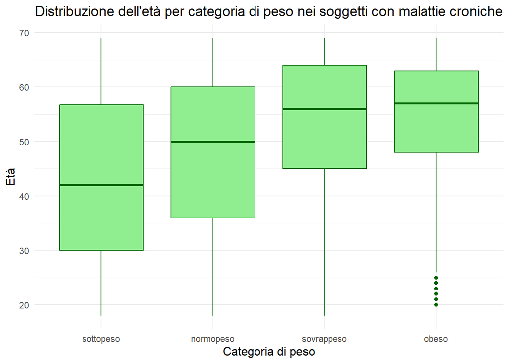

This boxplot illustrates the age distribution across weight categories among individuals diagnosed with chronic disease. A clear upward trend in median age can be observed from underweight to obese categories. Underweight individuals show a wider age spread and a lower median age, while overweight and obese individuals tend to be older, with higher median and upper quartile values. Outliers are present only in the obese group, concentrated in the younger age range. This pattern may suggest a potential association between higher BMI and older age among individuals with chronic disease. Further analysis would be needed to assess the statistical significance of these differences.

```
## Smoothing formula not specified. Using: y ~ x
## Smoothing formula not specified. Using: y ~ x
## Smoothing formula not specified. Using: y ~ x
```

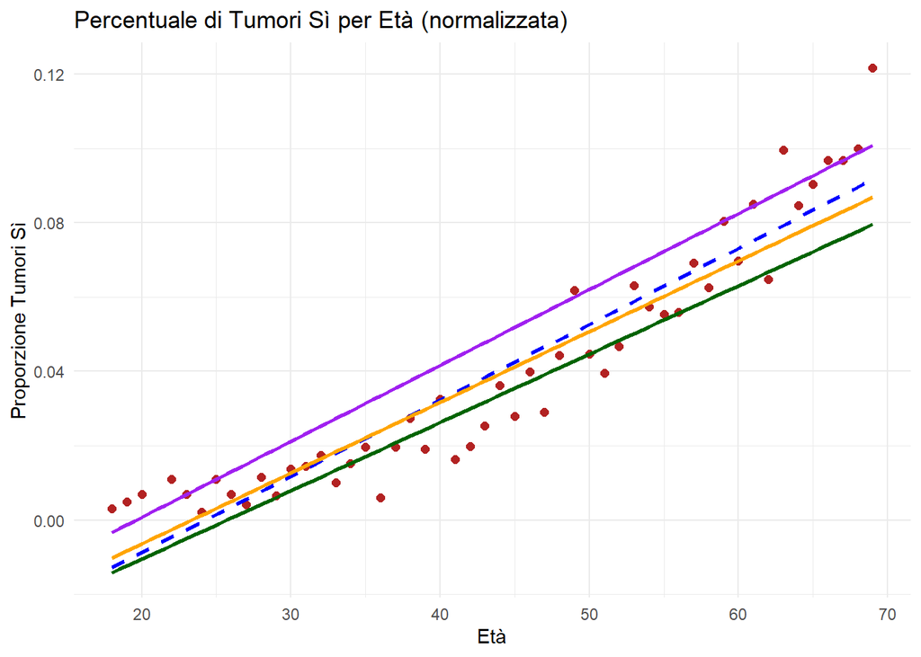

This scatter plot shows the proportion of respondents who answered “yes” to having a tumor, plotted against their age group. Each red dot represents the observed proportion in a given age. The following trend lines are included: - Blue dashed line: linear regression line, showing a clear positive correlation between age and tumor prevalence. - Green line: 25th percentile quantile regression, indicating the lower bound trend. - Orange line: 50th percentile (median) quantile regression, showing the central tendency. - Purple line: 75th percentile quantile regression, highlighting the upper bound trend. These quantile regressions help reveal variability across the distribution, especially at older ages, where the spread increases. Overall, the chart suggests a growing proportion of tumor-positive respondents with increasing age.

```
## Smoothing formula not specified. Using: y ~ x
## Smoothing formula not specified. Using: y ~ x
## Smoothing formula not specified. Using: y ~ x
```

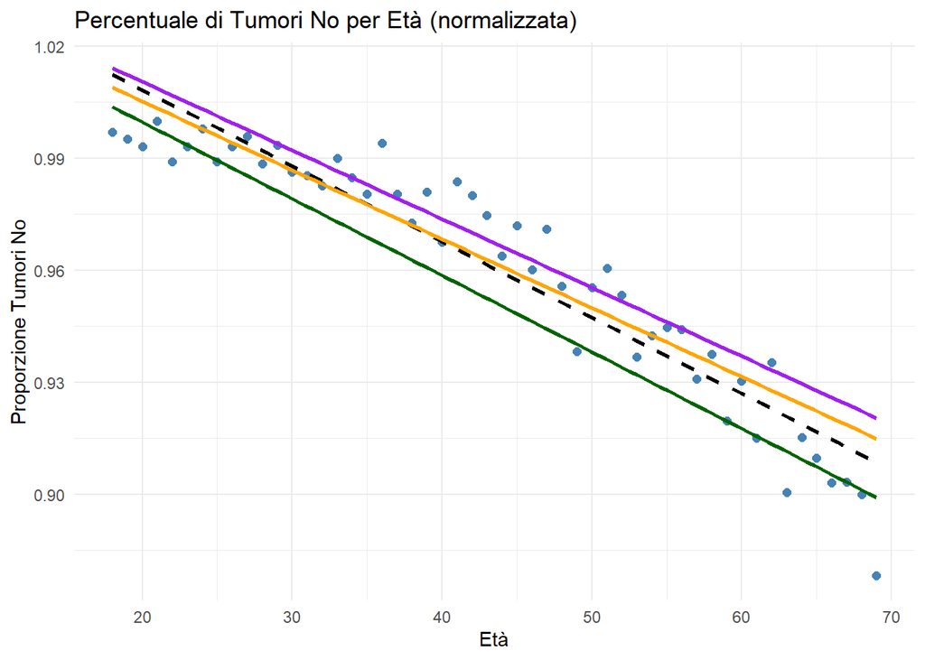

This normalized scatter plot shows the proportion of respondents who answered “no” to having a tumor, plotted against their age group. Each blue dot represents the observed proportion for a specific age. The plot includes the following trend lines: - Black dashed line: linear regression line, showing a slight negative trend in the proportion of “no” responses with age. - Green line: 25th percentile quantile regression, reflecting the lower bound trend. - Orange line: 50th percentile (median) quantile regression, indicating the central trend. - Purple line: 75th percentile quantile regression, representing the upper bound trend. Together, these lines help to visualize the distribution and variability in “no” tumor responses across ages. The chart suggests that younger respondents are more likely to report no history of tumors, while this proportion tends to decrease with age.

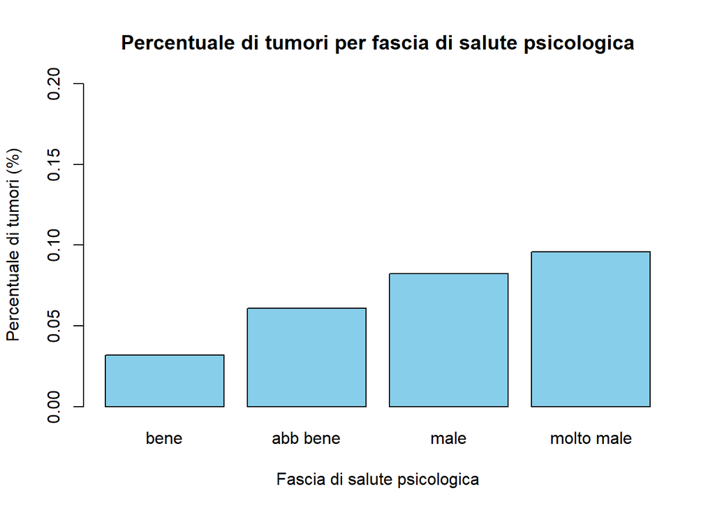

The chart shows an increasing trend: worse psychological health is associated with higher tumor percentage. “Very poor” mental health has the highest tumor rate; “good” has the lowest. Suggests a possible positive association

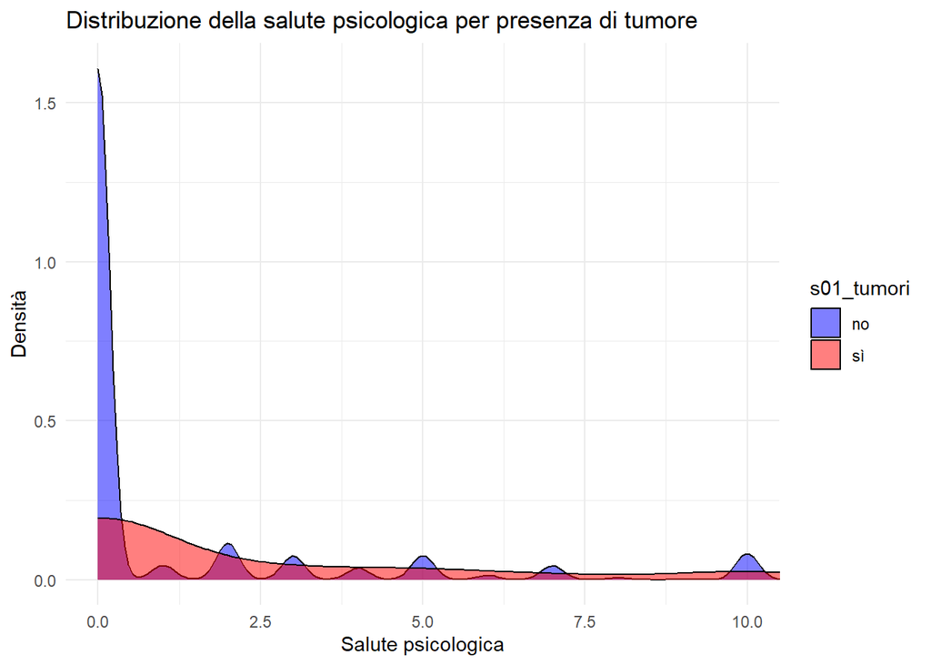

The plot shows that individuals without tumors (blue) tend to report better psychological health, with a strong peak near zero (high well-being). Those with tumors (red) have a flatter distribution, with relatively higher density in lower psychological health scores. This suggests that poor mental health may be more common among individuals with tumors.

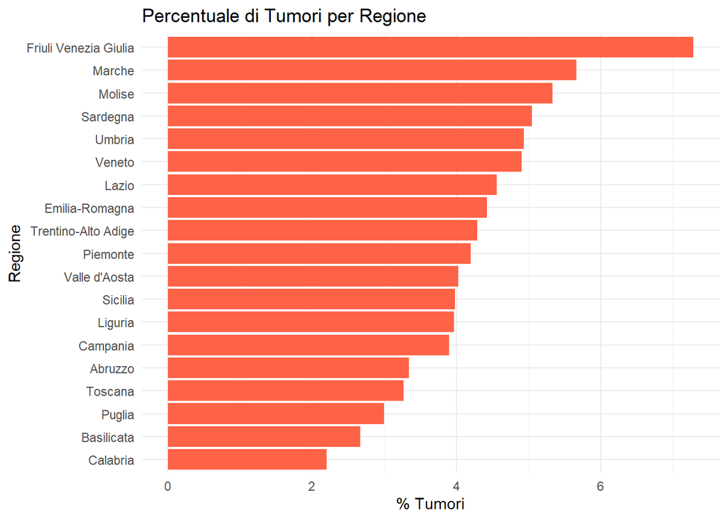

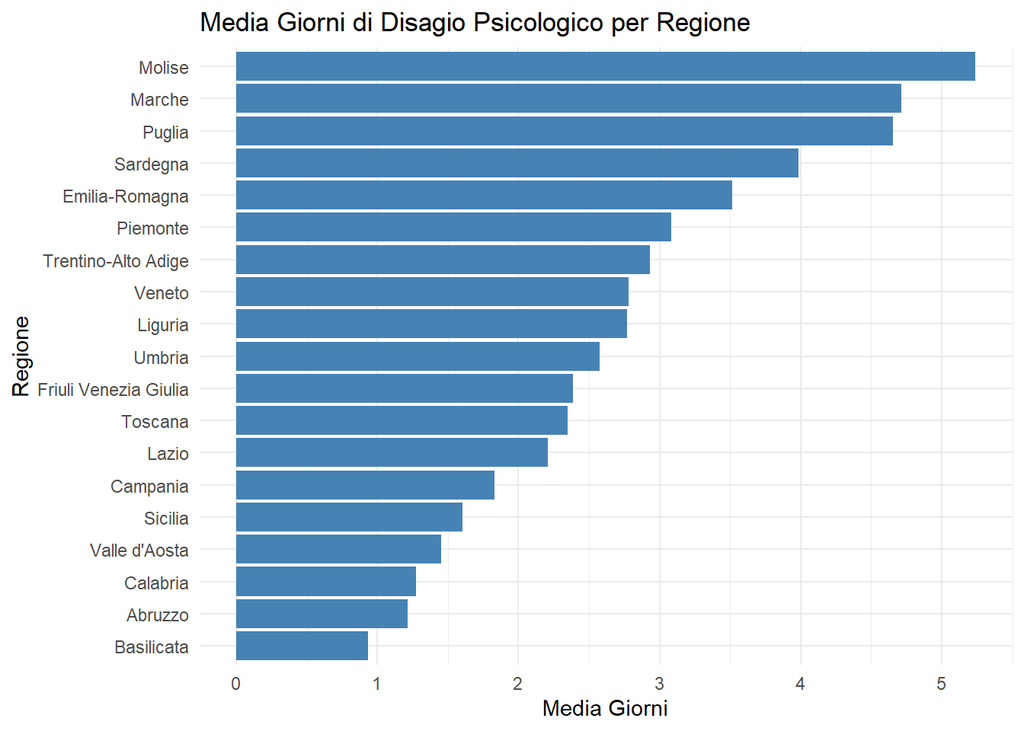

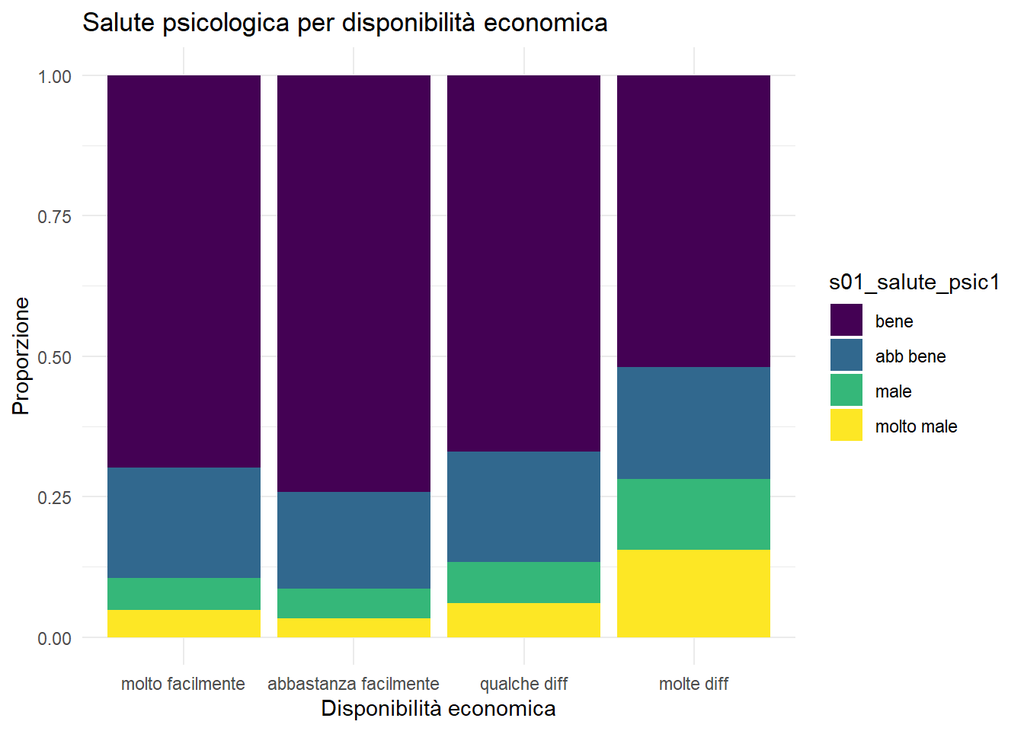

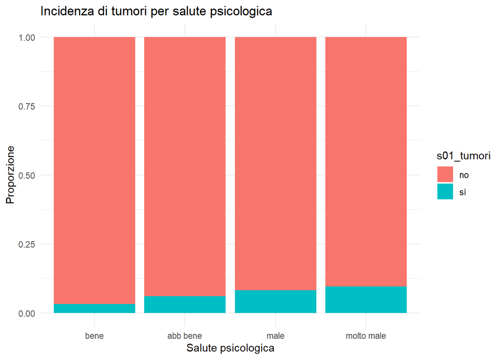

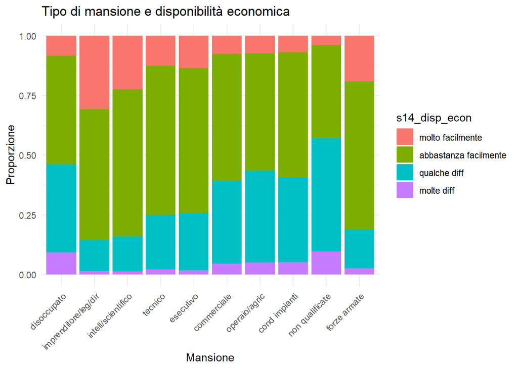

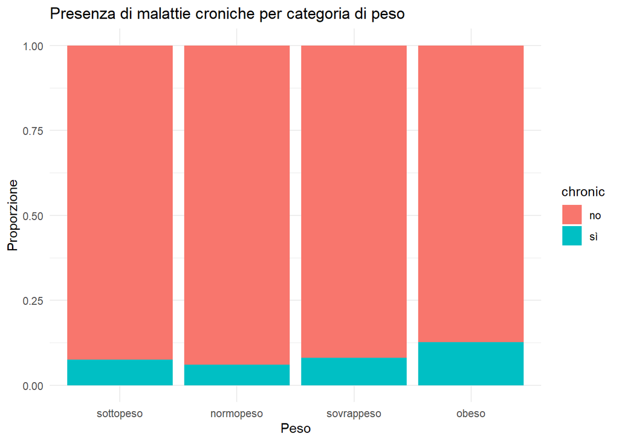

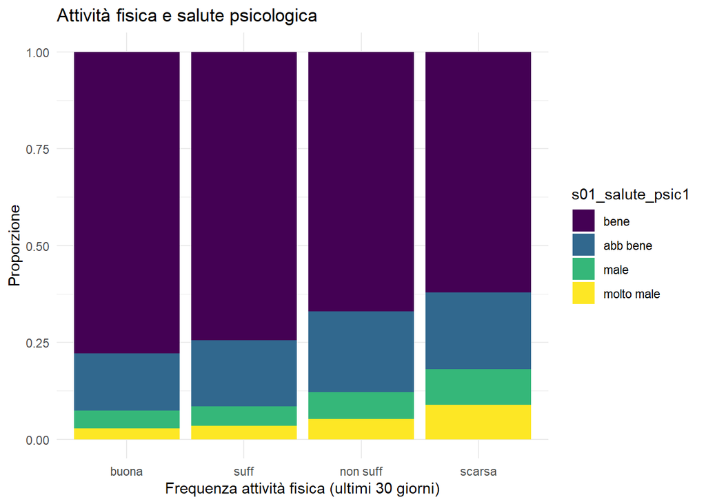

## Contingency tables

|  | totale_tumori | totale_non_tumori | Sum |
| --- | --- | --- | --- |
| bene | 671 | 20377 | 21048 |
| abb bene | 336 | 5189 | 5525 |
| male | 157 | 1749 | 1906 |
| molto male | 144 | 1357 | 1501 |
| Sum | 1308 | 28672 | 29980 |

|  | totale_tumori | totale_non_tumori | Sum |
| --- | --- | --- | --- |
| bene | 0.0223816 | 0.6796865 | 0.7020680 |
| abb bene | 0.0112075 | 0.1730821 | 0.1842895 |
| male | 0.0052368 | 0.0583389 | 0.0635757 |
| molto male | 0.0048032 | 0.0452635 | 0.0500667 |
| Sum | 0.0436291 | 0.9563709 | 1.0000000 |

|  | totale_tumori | totale_non_tumori |
| --- | --- | --- |
| bene | 0.0318795 | 0.9681205 |
| abb bene | 0.0608145 | 0.9391855 |
| male | 0.0823715 | 0.9176285 |
| molto male | 0.0959360 | 0.9040640 |

This table shows the distribution of tumor and non-tumor cases across different levels of psychological health: As psychological health worsens, the proportion of individuals with tumors increases: - “bene”: 3.19% with tumors, 96.81% without tumors - “abb bene”: 6.08% with tumors, 93.92% without tumors - “male”: 8.24% with tumors, 91.76% without tumors - “molto male”: 9.59% with tumors, 90.41% without tumors This suggests a negative correlation between psychological well-being and tumor prevalence. Poorer psychological health appears to be associated with a higher incidence of tumors.

```
## [1] -47.57907
```

```
## [1] -61.29786
```

```
## [1] -66.77003
```

Risk Ratio analysis using “bene” (good psychological health) as the reference level - prob_condizionata is a table of conditional probabilities where: Rows represent psychological health levels: 1 = “bene” (good), 2 = “abb bene” (fairly good), 3 = “male” (bad), 4 = “molto male” (very bad) Column 1 contains the probability of having a tumor (totale_tumori)

Overall interpretation: There is a clear negative association between psychological health and tumor prevalence. As psychological health worsens, the relative risk of having a tumor increases significantly.

```
## [1] 0.03292928
```

OR_bene = 0.03292928 This is the odds of having a tumor for individuals with “bene” (good psychological health). It means that for every 1 person with a tumor, there are approximately 30.4 people without a tumor in the “bene” group (since 1 / 0.0329 ≈ 30.4). In other words, the odds of having a tumor in this group are very low — around 3.3%.

```
## [1] 0.06475236
```

```
## [1] 0.08976558
```

```
## [1] 0.1061164
```

```
## [1] 3.222555
```

```
## [1] 222.2555
```

Interpretation: The odds of having a tumor for individuals with “molto male” psychological health are approximately 3.22 times higher than for those with “bene” psychological health. This means their odds are 222.26% higher than the reference group The odds for people in bad psychological health (mm) subjects of being Ill (tumor) are 222.26%% higher than for people with “bene”.

|  | bene | abb bene | male | molto male | Sum |
| --- | --- | --- | --- | --- | --- |
| totale_tumori | 671 | 336 | 157 | 144 | 1308 |
| totale_non_tumori | 20377 | 5189 | 1749 | 1357 | 28672 |
| Sum | 21048 | 5525 | 1906 | 1501 | 29980 |

|  | bene | abb bene | male | molto male | Sum |
| --- | --- | --- | --- | --- | --- |
| totale_tumori | 0.0223816 | 0.0112075 | 0.0052368 | 0.0048032 | 0.0436291 |
| totale_non_tumori | 0.6796865 | 0.1730821 | 0.0583389 | 0.0452635 | 0.9563709 |
| Sum | 0.7020680 | 0.1842895 | 0.0635757 | 0.0500667 | 1.0000000 |

|  | bene | abb bene | male | molto male |
| --- | --- | --- | --- | --- |
| totale_tumori | 0.5129969 | 0.2568807 | 0.1200306 | 0.1100917 |
| totale_non_tumori | 0.7106934 | 0.1809780 | 0.0610003 | 0.0473284 |

The values indicate the proportion of people with a specific psychological state among those with tumors and among those without tumors. Example interpretations: - 51.3% of the people with tumors report feeling “bene” - 25.7% of the people with tumors report feeling “abbastanza bene” - 12.0% of tumor cases fall under the “male” category - 11.0% of tumor cases are in the “molto male” category

Interpretation: - The percentage of people reporting “bene” is higher in the non-tumor group (71.1%) compared to the tumor group (51.3%), suggesting better psychological health is more common among those without tumors. - Conversely, worse psychological states (“male” and “molto male”) are more represented among those with tumors than those without. These differences may suggest an association between psychological health and tumor status

```
## [1] -27.8174
```

```
## [1] 41.94034
```

```
## [1] 96.77054
```

```
## [1] 132.6124
```

Overall interpretation: As psychological well-being decreases from “bene” to “molto male”, the relative risk of being in the tumor group increases significantly. This trend supports a potential association between poor mental health and tumor incidence.

Final summary: There is a clear increasing trend in the odds of being in the tumor group as self-reported psychological health worsens. This supports a possible association between poor mental health and higher tumor prevalence.

Data summary

| Name | ps1 |
| --- | --- |
| Number of rows | 29009 |
| Number of columns | 30 |
| _______________________ |  |
| Column type frequency: |  |
| character | 1 |
| factor | 22 |
| numeric | 7 |
| ________________________ |  |
| Group variables | None |

**Variable type: character**

| skim_variable | n_missing | complete_rate | min | max | empty | n_unique | whitespace |
| --- | --- | --- | --- | --- | --- | --- | --- |
| data_intervista | 0 | 1 | 10 | 10 | 0 | 357 | 0 |

**Variable type: factor**

| skim_variable | n_missing | complete_rate | ordered | n_unique | top_counts |
| --- | --- | --- | --- | --- | --- |
| regione | 0 | 1.00 | FALSE | 19 | Pie: 3105, Tos: 3074, Emi: 2889, Laz: 2777 |
| sesso_intervistato | 0 | 1.00 | FALSE | 2 | F: 14943, M: 14066 |
| s01_tumori | 0 | 1.00 | FALSE | 2 | no: 27730, sì: 1279 |
| s02_attiv_30_gg_quanto | 0 | 1.00 | FALSE | 4 | suf: 11034, non: 8313, sca: 5939, buo: 3723 |
| s03_fumo | 0 | 1.00 | FALSE | 2 | non: 16761, ha : 12248 |
| s03_fumo_att | 0 | 1.00 | FALSE | 3 | -99: 16761, fum: 6700, non: 5548 |
| s04_consu_frutta | 0 | 1.00 | FALSE | 4 | 1-2: 14783, 3-4: 11496, 5: 2002, 0: 728 |
| s14_stato_civ | 0 | 1.00 | FALSE | 4 | con: 15322, cel: 10968, sep: 2142, ved: 577 |
| s14_tit_stud | 0 | 1.00 | FALSE | 5 | dip: 14734, med: 7006, lau: 6607, ele: 581 |
| s14_disp_econ | 0 | 1.00 | FALSE | 4 | abb: 15091, qua: 9058, mol: 3292, mol: 1568 |
| s01_malattie_croniche | 0 | 1.00 | FALSE | 2 | no: 28694, sì: 315 |
| s01_insuff_renale | 0 | 1.00 | FALSE | 2 | no: 28758, sì: 251 |
| s01_bronchite | 0 | 1.00 | FALSE | 2 | no: 28321, sì: 688 |
| s01_asma_bronchiale | 0 | 1.00 | FALSE | 2 | no: 27795, sì: 1214 |
| s14_cittadin | 0 | 1.00 | FALSE | 3 | ita: 26839, str: 1698, dop: 472 |
| s18_qualita_aria | 12624 | 0.56 | FALSE | 5 | abb: 10146, mol: 3997, cat: 1760, -99: 279 |
| s09_mammo_eseg | 19061 | 0.34 | FALSE | 3 | sì: 8373, no: 1541, -99: 34 |
| s10_so_eseg | 15918 | 0.45 | FALSE | 3 | sì: 7360, no: 5623, -99: 108 |
| s14_codifica_mansione | 0 | 1.00 | FALSE | 10 | dis: 9517, ese: 4012, com: 3247, int: 3086 |
| peso | 0 | 1.00 | FALSE | 4 | nor: 15966, sov: 9203, obe: 2941, sot: 899 |
| chronic | 0 | 1.00 | FALSE | 2 | no: 26841, sì: 2168 |
| s01_salute_psic1 | 0 | 1.00 | TRUE | 4 | ben: 20385, abb: 5309, mal: 1864, mol: 1451 |

**Variable type: numeric**

| skim_variable | n_missing | complete_rate | mean | sd | p0 | p25 | p50 | p75 | p100 | hist |
| --- | --- | --- | --- | --- | --- | --- | --- | --- | --- | --- |
| id | 0 | 1 | 4337114.84 | 54978.81 | 4229291 | 4288893 | 4336708 | 4387626 | 4458199 | ▅▇▆▇▂ |
| s01_salute_psic | 0 | 1 | 2.75 | 6.40 | 0 | 0 | 0 | 2 | 30 | ▇▁▁▁▁ |
| s05_alcool_gg | 0 | 1 | 6.12 | 9.20 | 0 | 0 | 2 | 8 | 30 | ▇▁▁▁▁ |
| s07_eta | 0 | 1 | 45.87 | 14.32 | 18 | 34 | 48 | 58 | 69 | ▅▆▇▇▇ |
| s12_poco_inter_gg | 0 | 1 | 0.96 | 2.57 | 0 | 0 | 0 | 0 | 14 | ▇▁▁▁▁ |
| s01_tum_anni_diagnosi | 0 | 1 | -94.38 | 24.93 | -99 | -99 | -99 | -99 | 2016 | ▇▁▁▁▁ |
| count.1 | 0 | 1 | 0.09 | 0.32 | 0 | 0 | 0 | 0 | 4 | ▇▁▁▁▁ |

## Balancing the dataset

```
## 'data.frame':    29009 obs. of  17 variables:
##  $ id                   : chr  "synt_1" "synt_2" "synt_3" "synt_4" ...
##  $ regione              : Factor w/ 19 levels "Piemonte","Valle d'Aosta",..: 2 7 3 14 9 4 3 3 11 5 ...
##  $ sesso_intervistato   : Factor w/ 2 levels "F","M": 2 1 1 2 1 2 2 2 1 2 ...
##  $ s01_salute_psic      : num  11 2 2 0 3 19 4 7 3 0 ...
##  $ s01_tumori           : Factor w/ 2 levels "no","sì": 1 1 1 1 1 1 1 1 1 1 ...
##  $ s03_fumo             : Factor w/ 2 levels "ha fumato","non ha fumato": 1 2 1 2 2 1 1 1 2 2 ...
##  $ s04_consu_frutta     : Factor w/ 4 levels "0","1-2","3-4",..: 3 3 2 2 4 2 3 3 1 2 ...
##  $ s07_eta              : num  62 48 66 28 38 62 69 61 64 21 ...
##  $ s12_poco_inter_gg    : num  3 0 0 1 0 2 0 0 2 0 ...
##  $ s14_stato_civ        : Factor w/ 4 levels "coniugato","celibe/nubile",..: 1 2 1 2 1 3 1 1 1 2 ...
##  $ s14_tit_stud         : Factor w/ 5 levels "no titolo","elementare",..: 4 5 4 4 5 3 2 2 4 4 ...
##  $ s14_disp_econ        : Factor w/ 4 levels "molto facilmente",..: 3 2 2 3 2 2 2 2 2 2 ...
##  $ s14_cittadin         : Factor w/ 3 levels "ita","straniera",..: 1 1 1 1 3 1 1 1 1 1 ...
##  $ s14_codifica_mansione: Factor w/ 10 levels "disoccupato",..: 1 3 6 1 4 1 1 1 1 7 ...
##  $ peso                 : Factor w/ 4 levels "sottopeso","normopeso",..: 2 1 3 2 3 2 3 3 3 3 ...
##  $ chronic              : Factor w/ 2 levels "no","sì": 1 2 1 1 1 1 2 2 1 1 ...
##  $ s01_salute_psic1     : Ord.factor w/ 4 levels "bene"<"abb bene"<..: 3 2 2 1 2 3 2 2 2 1 ...
```

```
##
##     F     M
## 16860 12149
```

```
##
##    no    sì
## 14690 14319
```

Data summary

| Name | data_balanced2 |
| --- | --- |
| Number of rows | 29009 |
| Number of columns | 17 |
| _______________________ |  |
| Column type frequency: |  |
| character | 1 |
| factor | 13 |
| numeric | 3 |
| ________________________ |  |
| Group variables | None |

**Variable type: character**

| skim_variable | n_missing | complete_rate | min | max | empty | n_unique | whitespace |
| --- | --- | --- | --- | --- | --- | --- | --- |
| id | 0 | 1 | 6 | 10 | 0 | 29009 | 0 |

**Variable type: factor**

| skim_variable | n_missing | complete_rate | ordered | n_unique | top_counts |
| --- | --- | --- | --- | --- | --- |
| regione | 0 | 1 | FALSE | 19 | Fri: 3375, Pie: 3046, Emi: 2859, Laz: 2785 |
| sesso_intervistato | 0 | 1 | FALSE | 2 | F: 16860, M: 12149 |
| s01_tumori | 0 | 1 | FALSE | 2 | no: 14690, sì: 14319 |
| s03_fumo | 0 | 1 | FALSE | 2 | non: 15994, ha : 13015 |
| s04_consu_frutta | 0 | 1 | FALSE | 4 | 1-2: 13950, 3-4: 12156, 5: 2260, 0: 643 |
| s14_stato_civ | 0 | 1 | FALSE | 4 | con: 17448, cel: 8145, sep: 2503, ved: 913 |
| s14_tit_stud | 0 | 1 | FALSE | 5 | dip: 14284, med: 7972, lau: 6040, ele: 616 |
| s14_disp_econ | 0 | 1 | FALSE | 4 | abb: 14690, qua: 9243, mol: 3294, mol: 1782 |
| s14_cittadin | 0 | 1 | FALSE | 3 | ita: 27208, str: 1331, dop: 470 |
| s14_codifica_mansione | 0 | 1 | FALSE | 10 | dis: 11432, ese: 3792, int: 2991, com: 2926 |
| peso | 0 | 1 | FALSE | 4 | nor: 15572, sov: 9203, obe: 3373, sot: 861 |
| chronic | 0 | 1 | FALSE | 2 | no: 26139, sì: 2870 |
| s01_salute_psic1 | 0 | 1 | TRUE | 4 | abb: 12919, ben: 11690, mal: 2382, mol: 2018 |

**Variable type: numeric**

| skim_variable | n_missing | complete_rate | mean | sd | p0 | p25 | p50 | p75 | p100 | hist |
| --- | --- | --- | --- | --- | --- | --- | --- | --- | --- | --- |
| s01_salute_psic | 0 | 1 | 4.42 | 7.37 | 0 | 0 | 1 | 5 | 30 | ▇▁▁▁▁ |
| s07_eta | 0 | 1 | 50.38 | 13.79 | 18 | 41 | 53 | 62 | 69 | ▂▃▅▆▇ |
| s12_poco_inter_gg | 0 | 1 | 1.62 | 3.10 | 0 | 0 | 0 | 2 | 14 | ▇▁▁▁▁ |

**Models**

After rebalancing the dataset with ROSE, we go into depth with the analysis of some statistical models, in order to primarily understand how the variable tumor is influenced by the other variables.

The first model we are going to see is the logistic regression, which is a statistical model that works as a binary classifier, both used in descriptive and predictive analysis. The model estimates the lod-odds of the dependent variable as a linear combination of the covariates. The log-odds are then mapped into probabilities through the logistic function, which is enclosed in the interval (0,1). After the mapping, each observation has an assigned probability that assess the probability of belonging to a certain class.

```
##
## Call:
## glm(formula = s01_tumori ~ I(s07_eta)^2:s14_codifica_mansione +
##     sesso_intervistato + s03_fumo + s14_stato_civ + peso + s04_consu_frutta +
##     s14_cittadin + s14_tit_stud + regione + s12_poco_inter_gg +
##     s01_salute_psic + s14_disp_econ + chronic, family = "binomial",
##     data = data_balanced2)
##
## Coefficients:
##                                                       Estimate Std. Error
## (Intercept)                                          -2.430802   0.292477
## sesso_intervistatoM                                  -0.494788   0.029937
## s03_fumonon ha fumato                                -0.143148   0.027413
## s14_stato_civcelibe/nubile                           -0.257977   0.035592
## s14_stato_civvedovo                                   0.105624   0.081248
## s14_stato_civseparato/divorziato                     -0.067849   0.048312
## pesonormopeso                                        -0.227182   0.079965
## pesosovrappeso                                       -0.259402   0.082625
## pesoobeso                                            -0.134691   0.088175
## s04_consu_frutta1-2                                   0.074645   0.095097
## s04_consu_frutta3-4                                   0.138042   0.095911
## s04_consu_frutta5                                     0.105474   0.104819
## s14_cittadinstraniera                                -0.459024   0.067897
## s14_cittadindoppia                                   -0.135953   0.103886
## s14_tit_studelementare                               -0.515694   0.264804
## s14_tit_studmedia                                     0.062894   0.250657
## s14_tit_studdiploma                                   0.124516   0.250643
## s14_tit_studlaurea                                   -0.109405   0.252854
## regioneValle d'Aosta                                  0.004832   0.138100
## regioneTrentino-Alto Adige                            0.059308   0.086046
## regioneVeneto                                         0.096063   0.062881
## regioneFriuli Venezia Giulia                          0.459713   0.056727
## regioneLiguria                                        0.017592   0.075289
## regioneEmilia-Romagna                                 0.017379   0.058217
## regioneToscana                                       -0.260389   0.059498
## regioneUmbria                                         0.189169   0.092170
## regioneMarche                                         0.178513   0.085538
## regioneLazio                                          0.076397   0.059013
## regioneAbruzzo                                       -0.585180   0.102261
## regioneMolise                                         0.038270   0.155546
```

[output cut: 70 more lines]

```
## I(s07_eta):s14_codifica_mansionecommerciale           32.309  < 2e-16 ***
## I(s07_eta):s14_codifica_mansioneoperaio/agric         25.892  < 2e-16 ***
## I(s07_eta):s14_codifica_mansionecond impianti         20.933  < 2e-16 ***
## I(s07_eta):s14_codifica_mansionenon qualificate       28.853  < 2e-16 ***
## I(s07_eta):s14_codifica_mansioneforze armate          16.547  < 2e-16 ***
## ---
## Signif. codes:  0 '***' 0.001 '**' 0.01 '*' 0.05 '.' 0.1 ' ' 1
##
## (Dispersion parameter for binomial family taken to be 1)
##
##     Null deviance: 40210  on 29008  degrees of freedom
## Residual deviance: 33803  on 28957  degrees of freedom
## AIC: 33907
##
## Number of Fisher Scoring iterations: 4
```

| χ²(51) | 6406.78 |
| --- | --- |
| p | 0.00 |
| Pseudo-R² (Cragg-Uhler) | 0.26 |
| Pseudo-R² (McFadden) | 0.16 |
| AIC | 33907.49 |
| BIC | 34337.81 |

|  | Est. | S.E. | z val. | p |
| --- | --- | --- | --- | --- |
| (Intercept) | -2.43 | 0.29 | -8.31 | 0.00 |
| sesso_intervistatoM | -0.49 | 0.03 | -16.53 | 0.00 |
| s03_fumonon ha fumato | -0.14 | 0.03 | -5.22 | 0.00 |
| s14_stato_civcelibe/nubile | -0.26 | 0.04 | -7.25 | 0.00 |
| s14_stato_civvedovo | 0.11 | 0.08 | 1.30 | 0.19 |
| s14_stato_civseparato/divorziato | -0.07 | 0.05 | -1.40 | 0.16 |
| pesonormopeso | -0.23 | 0.08 | -2.84 | 0.00 |
| pesosovrappeso | -0.26 | 0.08 | -3.14 | 0.00 |
| pesoobeso | -0.13 | 0.09 | -1.53 | 0.13 |
| s04_consu_frutta1-2 | 0.07 | 0.10 | 0.78 | 0.43 |
| s04_consu_frutta3-4 | 0.14 | 0.10 | 1.44 | 0.15 |
| s04_consu_frutta5 | 0.11 | 0.10 | 1.01 | 0.31 |
| s14_cittadinstraniera | -0.46 | 0.07 | -6.76 | 0.00 |
| s14_cittadindoppia | -0.14 | 0.10 | -1.31 | 0.19 |
| s14_tit_studelementare | -0.52 | 0.26 | -1.95 | 0.05 |
| s14_tit_studmedia | 0.06 | 0.25 | 0.25 | 0.80 |
| s14_tit_studdiploma | 0.12 | 0.25 | 0.50 | 0.62 |
| s14_tit_studlaurea | -0.11 | 0.25 | -0.43 | 0.67 |
| regioneValle d’Aosta | 0.00 | 0.14 | 0.03 | 0.97 |
| regioneTrentino-Alto Adige | 0.06 | 0.09 | 0.69 | 0.49 |
| regioneVeneto | 0.10 | 0.06 | 1.53 | 0.13 |
| regioneFriuli Venezia Giulia | 0.46 | 0.06 | 8.10 | 0.00 |
| regioneLiguria | 0.02 | 0.08 | 0.23 | 0.82 |
| regioneEmilia-Romagna | 0.02 | 0.06 | 0.30 | 0.77 |
| regioneToscana | -0.26 | 0.06 | -4.38 | 0.00 |
| regioneUmbria | 0.19 | 0.09 | 2.05 | 0.04 |
| regioneMarche | 0.18 | 0.09 | 2.09 | 0.04 |
| regioneLazio | 0.08 | 0.06 | 1.29 | 0.20 |
| regioneAbruzzo | -0.59 | 0.10 | -5.72 | 0.00 |
| regioneMolise | 0.04 | 0.16 | 0.25 | 0.81 |
| regioneCampania | -0.11 | 0.07 | -1.60 | 0.11 |
| regionePuglia | -0.39 | 0.07 | -5.32 | 0.00 |
| regioneBasilicata | -0.41 | 0.11 | -3.63 | 0.00 |
| regioneCalabria | -0.93 | 0.12 | -7.88 | 0.00 |
| regioneSicilia | -0.06 | 0.07 | -0.87 | 0.39 |
| regioneSardegna | -0.14 | 0.07 | -2.04 | 0.04 |
| s12_poco_inter_gg | 0.07 | 0.01 | 12.53 | 0.00 |
| s01_salute_psic | 0.04 | 0.00 | 15.96 | 0.00 |
| s14_disp_econabbastanza facilmente | -0.04 | 0.04 | -0.95 | 0.34 |
| s14_disp_econqualche diff | -0.02 | 0.05 | -0.37 | 0.71 |
| s14_disp_econmolte diff | -0.08 | 0.07 | -1.06 | 0.29 |
| chronicsì | 0.28 | 0.05 | 6.14 | 0.00 |
| I(s07_eta):s14_codifica_mansionedisoccupato | 0.05 | 0.00 | 42.23 | 0.00 |
| I(s07_eta):s14_codifica_mansioneimprenditore/leg/dir | 0.05 | 0.00 | 27.89 | 0.00 |
| I(s07_eta):s14_codifica_mansioneintell/scientifico | 0.05 | 0.00 | 34.84 | 0.00 |
| I(s07_eta):s14_codifica_mansionetecnico | 0.05 | 0.00 | 29.04 | 0.00 |
| I(s07_eta):s14_codifica_mansioneesecutivo | 0.05 | 0.00 | 33.88 | 0.00 |
| I(s07_eta):s14_codifica_mansionecommerciale | 0.05 | 0.00 | 32.31 | 0.00 |
| I(s07_eta):s14_codifica_mansioneoperaio/agric | 0.04 | 0.00 | 25.89 | 0.00 |
| I(s07_eta):s14_codifica_mansionecond impianti | 0.05 | 0.00 | 20.93 | 0.00 |
| I(s07_eta):s14_codifica_mansionenon qualificate | 0.05 | 0.00 | 28.85 | 0.00 |
| I(s07_eta):s14_codifica_mansioneforze armate | 0.05 | 0.00 | 16.55 | 0.00 |

Standard errors: MLE

Running the logistic regression, many input variables seem to be significant for the analysis, meaning that there’s an association with the presence of tumor. In particular, gender, smoke, region, and the interaction between age and job seem to have a powerful impact. For example, gender MALE, with respect to FEMALE is negative and strongly significant, meaning that the risk of tumor is decreasing for males with respect to females.

We can also reasonably say that the model offers a good explanation of the response variable, as the null deviance is pretty higher than the residual deviance (thus, meaning that the model with covariates better explains the relationship with respect to the null model).

```
##
## Call:
## glm(formula = chronic ~ I(s07_eta)^2:s14_codifica_mansione +
##     sesso_intervistato + s03_fumo + s14_stato_civ + peso + s04_consu_frutta +
##     s14_cittadin + s14_tit_stud + regione + s12_poco_inter_gg +
##     s01_salute_psic + s14_disp_econ + s01_tumori, family = "binomial",
##     data = data_balanced2)
##
## Coefficients:
##                                                        Estimate Std. Error
## (Intercept)                                          -4.2622571  0.3920893
## sesso_intervistatoM                                   0.5136766  0.0463990
## s03_fumonon ha fumato                                -0.3197522  0.0428427
## s14_stato_civcelibe/nubile                            0.0486482  0.0595126
## s14_stato_civvedovo                                   0.2633331  0.0970196
## s14_stato_civseparato/divorziato                      0.2582994  0.0676211
## pesonormopeso                                        -0.6843841  0.1147082
## pesosovrappeso                                       -0.4378117  0.1174146
## pesoobeso                                            -0.2473825  0.1232464
## s04_consu_frutta1-2                                   0.3284425  0.1534451
## s04_consu_frutta3-4                                   0.5687260  0.1541947
## s04_consu_frutta5                                     0.5538499  0.1675232
## s14_cittadinstraniera                                 0.3234420  0.0951794
## s14_cittadindoppia                                    0.4358273  0.1404776
## s14_tit_studelementare                                0.4642951  0.3265708
## s14_tit_studmedia                                     0.3549492  0.3087386
## s14_tit_studdiploma                                   0.1595094  0.3092068
## s14_tit_studlaurea                                   -0.0157173  0.3155583
## regioneValle d'Aosta                                 -0.7776023  0.2760748
## regioneTrentino-Alto Adige                            0.5965696  0.1230531
## regioneVeneto                                         0.0805704  0.1032219
## regioneFriuli Venezia Giulia                          0.4447433  0.0868202
## regioneLiguria                                        0.6233206  0.1058604
## regioneEmilia-Romagna                                 0.1773466  0.0905854
## regioneToscana                                       -0.1937795  0.1035571
## regioneUmbria                                        -0.2828006  0.1572783
## regioneMarche                                        -0.4727708  0.1478649
## regioneLazio                                          0.1646376  0.0911777
## regioneAbruzzo                                        0.3771210  0.1500214
## regioneMolise                                        -0.0106442  0.2591195
```

[output cut: 70 more lines]

```
## I(s07_eta):s14_codifica_mansionecommerciale            3.117 0.001829 **
## I(s07_eta):s14_codifica_mansioneoperaio/agric         -0.229 0.819166
## I(s07_eta):s14_codifica_mansionecond impianti          5.038 4.72e-07 ***
## I(s07_eta):s14_codifica_mansionenon qualificate        9.074  < 2e-16 ***
## I(s07_eta):s14_codifica_mansioneforze armate           2.568 0.010226 *
## ---
## Signif. codes:  0 '***' 0.001 '**' 0.01 '*' 0.05 '.' 0.1 ' ' 1
##
## (Dispersion parameter for binomial family taken to be 1)
##
##     Null deviance: 18725  on 29008  degrees of freedom
## Residual deviance: 16955  on 28957  degrees of freedom
## AIC: 17059
##
## Number of Fisher Scoring iterations: 5
```

| χ²(51) | 1769.53 |
| --- | --- |
| p | 0.00 |
| Pseudo-R² (Cragg-Uhler) | 0.12 |
| Pseudo-R² (McFadden) | 0.09 |
| AIC | 17058.97 |
| BIC | 17489.29 |

|  | Est. | S.E. | z val. | p |
| --- | --- | --- | --- | --- |
| (Intercept) | -4.26 | 0.39 | -10.87 | 0.00 |
| sesso_intervistatoM | 0.51 | 0.05 | 11.07 | 0.00 |
| s03_fumonon ha fumato | -0.32 | 0.04 | -7.46 | 0.00 |
| s14_stato_civcelibe/nubile | 0.05 | 0.06 | 0.82 | 0.41 |
| s14_stato_civvedovo | 0.26 | 0.10 | 2.71 | 0.01 |
| s14_stato_civseparato/divorziato | 0.26 | 0.07 | 3.82 | 0.00 |
| pesonormopeso | -0.68 | 0.11 | -5.97 | 0.00 |
| pesosovrappeso | -0.44 | 0.12 | -3.73 | 0.00 |
| pesoobeso | -0.25 | 0.12 | -2.01 | 0.04 |
| s04_consu_frutta1-2 | 0.33 | 0.15 | 2.14 | 0.03 |
| s04_consu_frutta3-4 | 0.57 | 0.15 | 3.69 | 0.00 |
| s04_consu_frutta5 | 0.55 | 0.17 | 3.31 | 0.00 |
| s14_cittadinstraniera | 0.32 | 0.10 | 3.40 | 0.00 |
| s14_cittadindoppia | 0.44 | 0.14 | 3.10 | 0.00 |
| s14_tit_studelementare | 0.46 | 0.33 | 1.42 | 0.16 |
| s14_tit_studmedia | 0.35 | 0.31 | 1.15 | 0.25 |
| s14_tit_studdiploma | 0.16 | 0.31 | 0.52 | 0.61 |
| s14_tit_studlaurea | -0.02 | 0.32 | -0.05 | 0.96 |
| regioneValle d’Aosta | -0.78 | 0.28 | -2.82 | 0.00 |
| regioneTrentino-Alto Adige | 0.60 | 0.12 | 4.85 | 0.00 |
| regioneVeneto | 0.08 | 0.10 | 0.78 | 0.44 |
| regioneFriuli Venezia Giulia | 0.44 | 0.09 | 5.12 | 0.00 |
| regioneLiguria | 0.62 | 0.11 | 5.89 | 0.00 |
| regioneEmilia-Romagna | 0.18 | 0.09 | 1.96 | 0.05 |
| regioneToscana | -0.19 | 0.10 | -1.87 | 0.06 |
| regioneUmbria | -0.28 | 0.16 | -1.80 | 0.07 |
| regioneMarche | -0.47 | 0.15 | -3.20 | 0.00 |
| regioneLazio | 0.16 | 0.09 | 1.81 | 0.07 |
| regioneAbruzzo | 0.38 | 0.15 | 2.51 | 0.01 |
| regioneMolise | -0.01 | 0.26 | -0.04 | 0.97 |
| regioneCampania | -0.32 | 0.12 | -2.59 | 0.01 |
| regionePuglia | -0.15 | 0.12 | -1.25 | 0.21 |
| regioneBasilicata | 0.26 | 0.18 | 1.48 | 0.14 |
| regioneCalabria | 0.24 | 0.16 | 1.47 | 0.14 |
| regioneSicilia | -0.45 | 0.13 | -3.55 | 0.00 |
| regioneSardegna | 0.38 | 0.10 | 3.79 | 0.00 |
| s12_poco_inter_gg | 0.05 | 0.01 | 6.96 | 0.00 |
| s01_salute_psic | 0.02 | 0.00 | 7.27 | 0.00 |
| s14_disp_econabbastanza facilmente | 0.31 | 0.08 | 3.96 | 0.00 |
| s14_disp_econqualche diff | 0.58 | 0.08 | 6.80 | 0.00 |
| s14_disp_econmolte diff | 1.09 | 0.10 | 10.73 | 0.00 |
| s01_tumorisì | 0.31 | 0.05 | 6.70 | 0.00 |
| I(s07_eta):s14_codifica_mansionedisoccupato | 0.02 | 0.00 | 8.50 | 0.00 |
| I(s07_eta):s14_codifica_mansioneimprenditore/leg/dir | 0.02 | 0.00 | 8.51 | 0.00 |
| I(s07_eta):s14_codifica_mansioneintell/scientifico | 0.02 | 0.00 | 7.06 | 0.00 |
| I(s07_eta):s14_codifica_mansionetecnico | 0.02 | 0.00 | 5.49 | 0.00 |
| I(s07_eta):s14_codifica_mansioneesecutivo | 0.01 | 0.00 | 4.90 | 0.00 |
| I(s07_eta):s14_codifica_mansionecommerciale | 0.01 | 0.00 | 3.12 | 0.00 |
| I(s07_eta):s14_codifica_mansioneoperaio/agric | -0.00 | 0.00 | -0.23 | 0.82 |
| I(s07_eta):s14_codifica_mansionecond impianti | 0.02 | 0.00 | 5.04 | 0.00 |
| I(s07_eta):s14_codifica_mansionenon qualificate | 0.02 | 0.00 | 9.07 | 0.00 |
| I(s07_eta):s14_codifica_mansioneforze armate | 0.01 | 0.01 | 2.57 | 0.01 |

Standard errors: MLE

Also in this case, many covariates seem to be likely to influence the ‘chronic’ variable.

**Building an automated risk indicator**

Going back to the first model, we want to see how an individual is at risk based on its characteristics. We are going to try for it by using the balanced dataset, thus inserting the synthetic ids.

At first, we have to calculate the predicted probabilities of tumors.

Now, we can make a search by id in the dataset, in order to see how high is the probability for a certain individual to have a tumor.

```
##       id risk_prob
## 1 synt_1 0.7362759
```

```
##       id       regione sesso_intervistato s01_salute_psic s01_tumori  s03_fumo
## 1 synt_1 Valle d'Aosta                  M              11         no ha fumato
##   s04_consu_frutta s07_eta s12_poco_inter_gg s14_stato_civ s14_tit_stud
## 1              3-4      62                 3     coniugato      diploma
##   s14_disp_econ s14_cittadin s14_codifica_mansione      peso chronic
## 1  qualche diff          ita           disoccupato normopeso      no
##   s01_salute_psic1 risk_prob
## 1             male 0.7362759
```

We can also try to apply the prediction to the original dataset to see if it is coherent with our explanation.

```
## # A tibble: 1 × 2
##        id risk_prob
##     <int>     <dbl>
## 1 4365891     0.538
```

```
## # A tibble: 1 × 31
##        id regione  sesso_intervistato data_intervista s01_salute_psic s01_tumori
##     <int> <fct>    <fct>                        <dbl>           <dbl> <fct>
## 1 4365891 Sardegna M                               NA               0 no
## # ℹ 25 more variables: s02_attiv_30_gg_quanto <fct>, s03_fumo <fct>,
## #   s03_fumo_att <fct>, s04_consu_frutta <fct>, s05_alcool_gg <dbl>,
## #   s07_eta <int>, s12_poco_inter_gg <dbl>, s14_stato_civ <fct>,
## #   s14_tit_stud <fct>, s14_disp_econ <fct>, s01_malattie_croniche <fct>,
## #   s01_insuff_renale <fct>, s01_bronchite <fct>, s01_asma_bronchiale <fct>,
## #   s14_cittadin <fct>, s18_qualita_aria <fct>, s09_mammo_eseg <fct>,
## #   s10_so_eseg <fct>, s14_codifica_mansione <fct>, peso <fct>, …
```

In this case, id 4365891 has a probability of 0.54, associated to a high quantity of alcool drank in the last 30 days (20 out of 30) and 61 years old.

We can have a glance at the indicator and see whether, for different thresholds, it is a good classifier based on the real labeled variable for tumors.

```
## Area under the curve: 0.7604
```

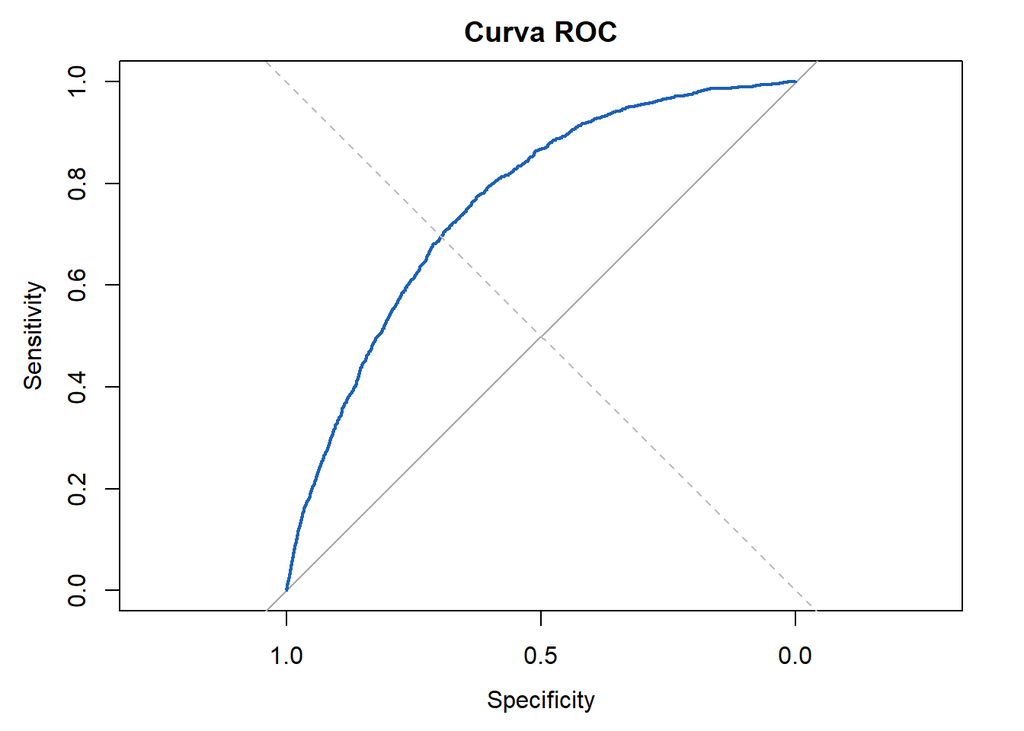

The ROC curve lies above the line of the random classifier, thus appearing to be highly performing in terms of classification, on the original model (which was highly unbalanced) with an AUC = 0.7604.

**Comparison with the null model**

```
##
## Call:
## glm(formula = s01_tumori ~ 1, family = "binomial", data = data_balanced2)
##
## Coefficients:
##             Estimate Std. Error z value Pr(>|z|)
## (Intercept) -0.02558    0.01174  -2.178   0.0294 *
## ---
## Signif. codes:  0 '***' 0.001 '**' 0.01 '*' 0.05 '.' 0.1 ' ' 1
##
## (Dispersion parameter for binomial family taken to be 1)
##
##     Null deviance: 40210  on 29008  degrees of freedom
## Residual deviance: 40210  on 29008  degrees of freedom
## AIC: 40212
##
## Number of Fisher Scoring iterations: 3
```

```
## Analysis of Deviance Table
##
## Model 1: s01_tumori ~ 1
## Model 2: s01_tumori ~ I(s07_eta)^2:s14_codifica_mansione + sesso_intervistato +
##     s03_fumo + s14_stato_civ + peso + s04_consu_frutta + s14_cittadin +
##     s14_tit_stud + regione + s12_poco_inter_gg + s01_salute_psic +
##     s14_disp_econ + chronic
##   Resid. Df Resid. Dev Df Deviance  Pr(>Chi)
## 1     29008      40210
## 2     28957      33803 51   6406.8 < 2.2e-16 ***
## ---
## Signif. codes:  0 '***' 0.001 '**' 0.01 '*' 0.05 '.' 0.1 ' ' 1
```

Anova is a test that compare two nested model, in which the first one is the simpler one and the second one is the more complex one, by comparing their deviance: if its reduction is significant, then the added variables improve the model. Null hypothesis is: all the added coefficient are = 0.

Based on the Anova test, p-value is below 0.05, thus we can reject the null hypothesis and assess that the full model is statistically better in explaining the data.

```
## [1] 0.1593318
```

This element shows that the model explains around 15.9% of deviance with respect to the null model, which can be considered moderately good.

Now, are going to see whether similar results can be achieved using the chronic + tumor variable as response. We need to create a new binary variable, that assumes value = 1 if there’s an illness, 0 otherwise:

Again, we need to rebalance the dataset based on the new variable:

```
## 'data.frame':    29009 obs. of  16 variables:
##  $ id                   : chr  "synt_ct_1" "synt_ct_2" "synt_ct_3" "synt_ct_4" ...
##  $ regione              : Factor w/ 19 levels "Piemonte","Valle d'Aosta",..: 19 7 14 7 11 8 8 7 10 14 ...
##  $ sesso_intervistato   : Factor w/ 2 levels "F","M": 2 1 1 2 1 1 1 2 2 1 ...
##  $ s01_salute_psic      : num  0 15 4 2 6 0 1 1 0 2 ...
##  $ s03_fumo             : Factor w/ 2 levels "ha fumato","non ha fumato": 2 2 2 1 2 2 2 2 2 1 ...
##  $ s04_consu_frutta     : Factor w/ 4 levels "0","1-2","3-4",..: 2 2 2 3 2 3 3 3 3 4 ...
##  $ s07_eta              : num  57 64 59 47 47 32 37 27 58 68 ...
##  $ s12_poco_inter_gg    : num  0 0 6 0 1 0 0 0 0 0 ...
##  $ s14_stato_civ        : Factor w/ 4 levels "coniugato","celibe/nubile",..: 1 1 3 1 1 2 2 2 1 1 ...
##  $ s14_tit_stud         : Factor w/ 5 levels "no titolo","elementare",..: 5 4 3 5 4 5 5 4 3 3 ...
##  $ s14_disp_econ        : Factor w/ 4 levels "molto facilmente",..: 1 3 3 3 3 2 2 2 3 2 ...
##  $ s14_cittadin         : Factor w/ 3 levels "ita","straniera",..: 1 1 1 1 2 1 1 1 1 1 ...
##  $ s14_codifica_mansione: Factor w/ 10 levels "disoccupato",..: 4 1 1 2 9 4 4 5 1 1 ...
##  $ peso                 : Factor w/ 4 levels "sottopeso","normopeso",..: 4 2 4 2 3 2 2 2 3 3 ...
##  $ chronic_tumor_cat    : Factor w/ 2 levels "no","sì": 1 1 1 1 1 1 1 1 1 1 ...
##  $ s01_salute_psic1     : Ord.factor w/ 4 levels "bene"<"abb bene"<..: 1 3 2 2 2 1 2 2 1 2 ...
```

```
##
##     F     M
## 15550 13459
```

```
##
##    no    sì
## 14690 14319
```

Data summary

| Name | data_balanced_chronic_tum… |
| --- | --- |
| Number of rows | 29009 |
| Number of columns | 16 |
| _______________________ |  |
| Column type frequency: |  |
| character | 1 |
| factor | 12 |
| numeric | 3 |
| ________________________ |  |
| Group variables | None |

**Variable type: character**

| skim_variable | n_missing | complete_rate | min | max | empty | n_unique | whitespace |
| --- | --- | --- | --- | --- | --- | --- | --- |
| id | 0 | 1 | 9 | 13 | 0 | 29009 | 0 |

**Variable type: factor**

| skim_variable | n_missing | complete_rate | ordered | n_unique | top_counts |
| --- | --- | --- | --- | --- | --- |
| regione | 0 | 1 | FALSE | 19 | Pie: 3193, Emi: 2976, Laz: 2852, Fri: 2839 |
| sesso_intervistato | 0 | 1 | FALSE | 2 | F: 15550, M: 13459 |
| s03_fumo | 0 | 1 | FALSE | 2 | non: 15649, ha : 13360 |
| s04_consu_frutta | 0 | 1 | FALSE | 4 | 1-2: 14565, 3-4: 11577, 5: 2102, 0: 765 |
| s14_stato_civ | 0 | 1 | FALSE | 4 | con: 16074, cel: 9671, sep: 2453, ved: 811 |
| s14_tit_stud | 0 | 1 | FALSE | 5 | dip: 14277, med: 7754, lau: 6171, ele: 728 |
| s14_disp_econ | 0 | 1 | FALSE | 4 | abb: 14510, qua: 9308, mol: 3223, mol: 1968 |
| s14_cittadin | 0 | 1 | FALSE | 3 | ita: 26908, str: 1582, dop: 519 |
| s14_codifica_mansione | 0 | 1 | FALSE | 10 | dis: 10613, ese: 3877, com: 3083, int: 2960 |
| peso | 0 | 1 | FALSE | 4 | nor: 15024, sov: 9426, obe: 3653, sot: 906 |
| chronic_tumor_cat | 0 | 1 | FALSE | 2 | no: 14690, sì: 14319 |
| s01_salute_psic1 | 0 | 1 | TRUE | 4 | abb: 12804, ben: 12124, mal: 2269, mol: 1812 |

**Variable type: numeric**

| skim_variable | n_missing | complete_rate | mean | sd | p0 | p25 | p50 | p75 | p100 | hist |
| --- | --- | --- | --- | --- | --- | --- | --- | --- | --- | --- |
| s01_salute_psic | 0 | 1 | 4.12 | 7.14 | 0 | 0 | 1 | 4 | 30 | ▇▁▁▁▁ |
| s07_eta | 0 | 1 | 48.50 | 14.30 | 18 | 38 | 51 | 60 | 69 | ▃▃▅▆▇ |
| s12_poco_inter_gg | 0 | 1 | 1.50 | 2.95 | 0 | 0 | 0 | 1 | 14 | ▇▁▁▁▁ |

Let’s try again for the logistic regression, with the new dataset:

```
##
## Call:
## glm(formula = chronic_tumor_cat ~ I(s07_eta)^2:s14_codifica_mansione +
##     sesso_intervistato + s03_fumo + s14_stato_civ + peso + s04_consu_frutta +
##     s14_cittadin + s14_tit_stud + regione + s12_poco_inter_gg +
##     s01_salute_psic + s14_disp_econ, family = "binomial", data = data_balanced_chronic_tumor)
##
## Coefficients:
##                                                       Estimate Std. Error
## (Intercept)                                          -1.559632   0.288791
## sesso_intervistatoM                                  -0.064574   0.027999
## s03_fumonon ha fumato                                -0.238698   0.025955
## s14_stato_civcelibe/nubile                            0.047760   0.033118
## s14_stato_civvedovo                                   0.144965   0.082667
## s14_stato_civseparato/divorziato                     -0.086210   0.046869
## pesonormopeso                                        -0.218201   0.074014
## pesosovrappeso                                       -0.107749   0.076536
## pesoobeso                                             0.147673   0.081668
## s04_consu_frutta1-2                                  -0.167444   0.081161
## s04_consu_frutta3-4                                  -0.110330   0.082203
## s04_consu_frutta5                                    -0.145189   0.092623
## s14_cittadinstraniera                                -0.044186   0.057639
## s14_cittadindoppia                                    0.204838   0.095205
## s14_tit_studelementare                                0.089013   0.267003
## s14_tit_studmedia                                     0.278476   0.256090
## s14_tit_studdiploma                                   0.208323   0.255933
## s14_tit_studlaurea                                    0.120942   0.257847
## regioneValle d'Aosta                                  0.110936   0.123762
## regioneTrentino-Alto Adige                           -0.008068   0.078208
## regioneVeneto                                         0.162186   0.060019
## regioneFriuli Venezia Giulia                          0.263533   0.055370
## regioneLiguria                                        0.017724   0.067723
## regioneEmilia-Romagna                                -0.164154   0.054275
## regioneToscana                                       -0.355619   0.055416
## regioneUmbria                                        -0.056392   0.085025
## regioneMarche                                         0.041965   0.083984
## regioneLazio                                         -0.081117   0.055145
## regioneAbruzzo                                       -0.514536   0.094395
## regioneMolise                                        -0.205142   0.152500
## regioneCampania                                      -0.356495   0.067153
```

[output cut: 67 more lines]

```
## I(s07_eta):s14_codifica_mansionecommerciale           19.828  < 2e-16 ***
## I(s07_eta):s14_codifica_mansioneoperaio/agric         16.714  < 2e-16 ***
## I(s07_eta):s14_codifica_mansionecond impianti         13.389  < 2e-16 ***
## I(s07_eta):s14_codifica_mansionenon qualificate       18.022  < 2e-16 ***
## I(s07_eta):s14_codifica_mansioneforze armate           6.221 4.92e-10 ***
## ---
## Signif. codes:  0 '***' 0.001 '**' 0.01 '*' 0.05 '.' 0.1 ' ' 1
##
## (Dispersion parameter for binomial family taken to be 1)
##
##     Null deviance: 40210  on 29008  degrees of freedom
## Residual deviance: 36420  on 28958  degrees of freedom
## AIC: 36522
##
## Number of Fisher Scoring iterations: 4
```

| χ²(50) | 3789.94 |
| --- | --- |
| p | 0.00 |
| Pseudo-R² (Cragg-Uhler) | 0.16 |
| Pseudo-R² (McFadden) | 0.09 |
| AIC | 36522.33 |
| BIC | 36944.37 |

|  | Est. | S.E. | z val. | p |
| --- | --- | --- | --- | --- |
| (Intercept) | -1.56 | 0.29 | -5.40 | 0.00 |
| sesso_intervistatoM | -0.06 | 0.03 | -2.31 | 0.02 |
| s03_fumonon ha fumato | -0.24 | 0.03 | -9.20 | 0.00 |
| s14_stato_civcelibe/nubile | 0.05 | 0.03 | 1.44 | 0.15 |
| s14_stato_civvedovo | 0.14 | 0.08 | 1.75 | 0.08 |
| s14_stato_civseparato/divorziato | -0.09 | 0.05 | -1.84 | 0.07 |
| pesonormopeso | -0.22 | 0.07 | -2.95 | 0.00 |
| pesosovrappeso | -0.11 | 0.08 | -1.41 | 0.16 |
| pesoobeso | 0.15 | 0.08 | 1.81 | 0.07 |
| s04_consu_frutta1-2 | -0.17 | 0.08 | -2.06 | 0.04 |
| s04_consu_frutta3-4 | -0.11 | 0.08 | -1.34 | 0.18 |
| s04_consu_frutta5 | -0.15 | 0.09 | -1.57 | 0.12 |
| s14_cittadinstraniera | -0.04 | 0.06 | -0.77 | 0.44 |
| s14_cittadindoppia | 0.20 | 0.10 | 2.15 | 0.03 |
| s14_tit_studelementare | 0.09 | 0.27 | 0.33 | 0.74 |
| s14_tit_studmedia | 0.28 | 0.26 | 1.09 | 0.28 |
| s14_tit_studdiploma | 0.21 | 0.26 | 0.81 | 0.42 |
| s14_tit_studlaurea | 0.12 | 0.26 | 0.47 | 0.64 |
| regioneValle d’Aosta | 0.11 | 0.12 | 0.90 | 0.37 |
| regioneTrentino-Alto Adige | -0.01 | 0.08 | -0.10 | 0.92 |
| regioneVeneto | 0.16 | 0.06 | 2.70 | 0.01 |
| regioneFriuli Venezia Giulia | 0.26 | 0.06 | 4.76 | 0.00 |
| regioneLiguria | 0.02 | 0.07 | 0.26 | 0.79 |
| regioneEmilia-Romagna | -0.16 | 0.05 | -3.02 | 0.00 |
| regioneToscana | -0.36 | 0.06 | -6.42 | 0.00 |
| regioneUmbria | -0.06 | 0.09 | -0.66 | 0.51 |
| regioneMarche | 0.04 | 0.08 | 0.50 | 0.62 |
| regioneLazio | -0.08 | 0.06 | -1.47 | 0.14 |
| regioneAbruzzo | -0.51 | 0.09 | -5.45 | 0.00 |
| regioneMolise | -0.21 | 0.15 | -1.35 | 0.18 |
| regioneCampania | -0.36 | 0.07 | -5.31 | 0.00 |
| regionePuglia | -0.83 | 0.07 | -11.39 | 0.00 |
| regioneBasilicata | -0.87 | 0.11 | -7.59 | 0.00 |
| regioneCalabria | -0.21 | 0.10 | -2.20 | 0.03 |
| regioneSicilia | -0.27 | 0.07 | -3.88 | 0.00 |
| regioneSardegna | 0.10 | 0.06 | 1.53 | 0.13 |
| s12_poco_inter_gg | 0.09 | 0.01 | 15.40 | 0.00 |
| s01_salute_psic | 0.03 | 0.00 | 13.37 | 0.00 |
| s14_disp_econabbastanza facilmente | 0.02 | 0.04 | 0.47 | 0.64 |
| s14_disp_econqualche diff | 0.19 | 0.05 | 4.00 | 0.00 |
| s14_disp_econmolte diff | 0.23 | 0.07 | 3.45 | 0.00 |
| I(s07_eta):s14_codifica_mansionedisoccupato | 0.03 | 0.00 | 30.26 | 0.00 |
| I(s07_eta):s14_codifica_mansioneimprenditore/leg/dir | 0.03 | 0.00 | 17.18 | 0.00 |
| I(s07_eta):s14_codifica_mansioneintell/scientifico | 0.03 | 0.00 | 22.87 | 0.00 |
| I(s07_eta):s14_codifica_mansionetecnico | 0.03 | 0.00 | 20.28 | 0.00 |
| I(s07_eta):s14_codifica_mansioneesecutivo | 0.03 | 0.00 | 22.80 | 0.00 |
| I(s07_eta):s14_codifica_mansionecommerciale | 0.03 | 0.00 | 19.83 | 0.00 |
| I(s07_eta):s14_codifica_mansioneoperaio/agric | 0.03 | 0.00 | 16.71 | 0.00 |
| I(s07_eta):s14_codifica_mansionecond impianti | 0.03 | 0.00 | 13.39 | 0.00 |
| I(s07_eta):s14_codifica_mansionenon qualificate | 0.03 | 0.00 | 18.02 | 0.00 |
| I(s07_eta):s14_codifica_mansioneforze armate | 0.02 | 0.00 | 6.22 | 0.00 |

Standard errors: MLE

As expected, many coefficients are significant; moreover, the residual deviance seems to be considerably lower than the null deviance.

**Poisson regression**

Poisson regression is a statistical model used to predict count data — that is, data that represents the number of times an event occurs. In this case, the event is the presence of tumors, and we are going to analyze it with respect to age and psychological health.

Here, coefficients represent log changes in the expected counts: an increase of 1 in age leads to an increase of exp(coef) in y.

At first, we need to build the dataset to use:

Psychological health, in our case is set to be ordered (we’are going to use it later on), but in this case we want to see how each level influences the response variable, thus we are going to temporairly treat it as unordered.

Poisson regression with offset:

```
##
## Call:
## glm(formula = n ~ I(s07_eta)^2 + s01_salute_psic1, family = poisson,
##     data = ps_llm, offset = log(tot))
##
## Coefficients:
##                              Estimate Std. Error z value Pr(>|z|)
## (Intercept)                -2.4545234  0.0417815  -58.75   <2e-16 ***
## I(s07_eta)                  0.0297578  0.0007144   41.65   <2e-16 ***
## s01_salute_psic1abb bene    0.1971678  0.0190365   10.36   <2e-16 ***
## s01_salute_psic1male        0.4507442  0.0287437   15.68   <2e-16 ***
## s01_salute_psic1molto male  0.4634721  0.0305194   15.19   <2e-16 ***
## ---
## Signif. codes:  0 '***' 0.001 '**' 0.01 '*' 0.05 '.' 0.1 ' ' 1
##
## (Dispersion parameter for poisson family taken to be 1)
##
##     Null deviance: 2790.74  on 204  degrees of freedom
## Residual deviance:  362.78  on 200  degrees of freedom
## AIC: 1478.9
##
## Number of Fisher Scoring iterations: 4
```

Poisson regression without offset:

```
##
## Call:
## glm(formula = n ~ I(s07_eta)^2 + s01_salute_psic1, family = poisson,
##     data = ps_llm)
##
## Coefficients:
##                              Estimate Std. Error z value Pr(>|z|)
## (Intercept)                 1.4887003  0.0411268   36.20   <2e-16 ***
## I(s07_eta)                  0.0608362  0.0006956   87.46   <2e-16 ***
## s01_salute_psic1abb bene    0.3102107  0.0190344   16.30   <2e-16 ***
## s01_salute_psic1male       -1.0732737  0.0287130  -37.38   <2e-16 ***
## s01_salute_psic1molto male -1.2357230  0.0305047  -40.51   <2e-16 ***
## ---
## Signif. codes:  0 '***' 0.001 '**' 0.01 '*' 0.05 '.' 0.1 ' ' 1
##
## (Dispersion parameter for poisson family taken to be 1)
##
##     Null deviance: 15901.1  on 204  degrees of freedom
## Residual deviance:  1239.5  on 200  degrees of freedom
## AIC: 2355.7
##
## Number of Fisher Scoring iterations: 4
```

Offset makes it possible to model rates instead of raw counts. In the first case, we are looking at the count of individuals with tumor or not divided by the total population.

We can compare the two models, in which the covariates are statistically significant, by using AIC:

```
## [1] 1478.929
```

```
## [1] 2355.653
```

For the first model (with the offset), as expected, AIC is significantly lower than the second one, suggesting that it balances better model fit with complexity.

However, looking at the plots we can see that they are both quite explanatory. The plot including the offset seems to be more linear in the relationship between age and count of tumors.

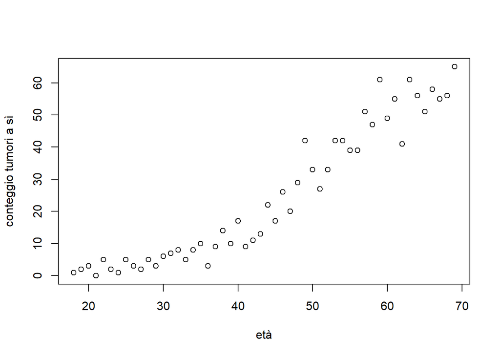

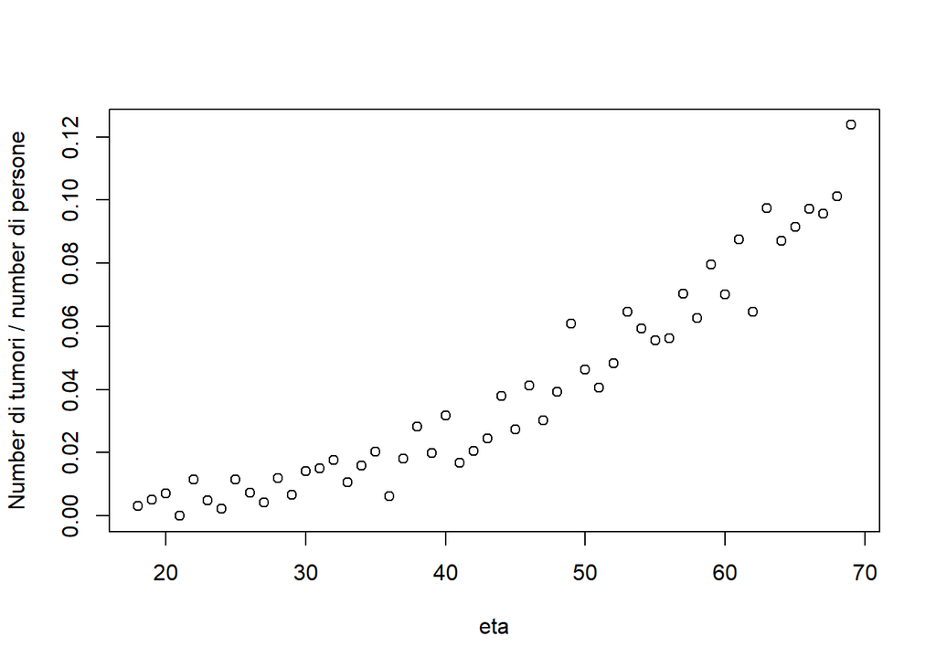

We can also try for an interaction model between age and psychological health, in order to see whether age has a different impact for different levels of psychological health:

```
## Analysis of Deviance Table
##
## Model 1: n ~ I(s07_eta)^2 + s01_salute_psic1
## Model 2: n ~ I(s07_eta)^2 * s01_salute_psic1
##   Resid. Df Resid. Dev Df Deviance  Pr(>Chi)
## 1       200     362.78
## 2       197     272.92  3   89.861 < 2.2e-16 ***
## ---
## Signif. codes:  0 '***' 0.001 '**' 0.01 '*' 0.05 '.' 0.1 ' ' 1
```

Interaction seems to be significant.

Now, we have to check for overdispersion, as in the case of Poisson regression one assumption is that the mean and the variance are equal. By the way, in reality variance is often greater or lower than the mean.

```
##
##  Dispersion test
##
## data:  m_llm
## z = 4.8754, p-value = 1.086e-06
## alternative hypothesis: true alpha is not equal to 0
## sample estimates:
##     alpha
## 0.6902293
```

```
## [1] 1.755717
```

These two indicators should be analyzed together.

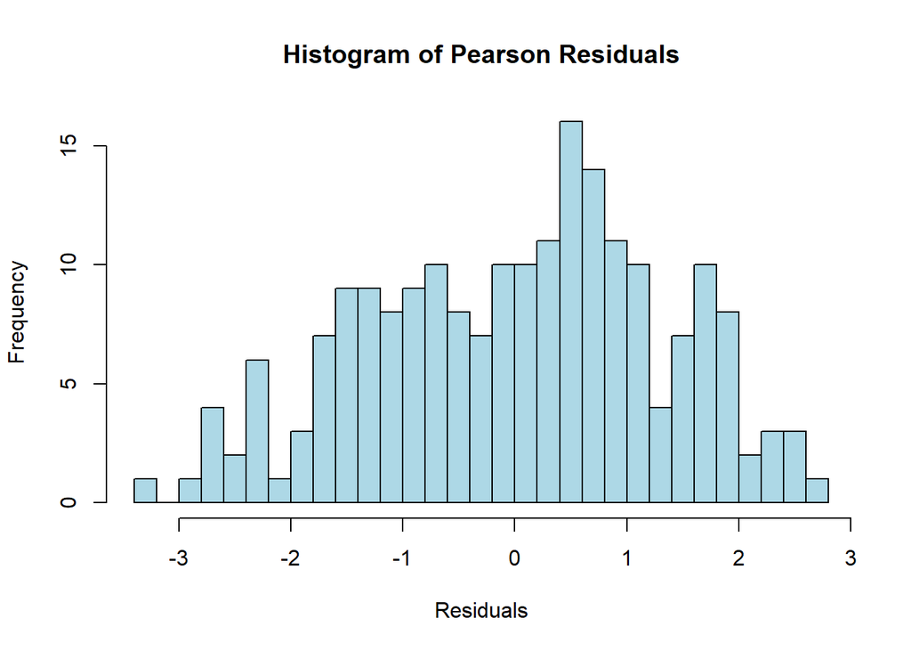

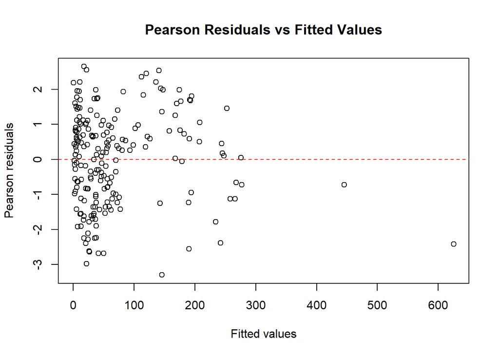

Looking at Pearson Residuals, it seems that there’s no clear pattern, and the majority of them is distributed around 0. This suggests that the model may be quite good.

We can try for a quasi-poisson model, in order to see if it performs better. The quasi-Poisson model is an extension of the standard Poisson regression used for count data.

This alternative allows the variance to differ from the mean by estimating a dispersion parameter directly from the data, making it more flexible and realistic. While the coefficient estimates remain the same, the quasi-Poisson model adjusts the standard errors and significance tests, providing more reliable inference under dispersion:

```
##
## Call:
## glm(formula = n ~ I(s07_eta)^2 * s01_salute_psic1, family = quasipoisson,
##     data = ps_llm, offset = log(tot))
##
## Coefficients:
##                                        Estimate Std. Error t value Pr(>|t|)
## (Intercept)                           -2.827387   0.081925 -34.512  < 2e-16 ***
## I(s07_eta)                             0.036495   0.001438  25.386  < 2e-16 ***
## s01_salute_psic1abb bene               0.571835   0.106210   5.384 2.06e-07 ***
## s01_salute_psic1male                   1.301130   0.164142   7.927 1.63e-13 ***
## s01_salute_psic1molto male             1.726005   0.169107  10.207  < 2e-16 ***
## I(s07_eta):s01_salute_psic1abb bene   -0.006770   0.001870  -3.620 0.000374 ***
## I(s07_eta):s01_salute_psic1male       -0.015230   0.002886  -5.278 3.44e-07 ***
## I(s07_eta):s01_salute_psic1molto male -0.022843   0.003031  -7.536 1.72e-12 ***
## ---
## Signif. codes:  0 '***' 0.001 '**' 0.01 '*' 0.05 '.' 0.1 ' ' 1
##
## (Dispersion parameter for quasipoisson family taken to be 1.316823)
##
##     Null deviance: 2790.74  on 204  degrees of freedom
## Residual deviance:  272.92  on 197  degrees of freedom
## AIC: NA
##
## Number of Fisher Scoring iterations: 4
```

The main difference in the two models is that the Dispersion Parameter is 1.316823 for the quasi-poisson, compared to 1 for the poisson: the quasi-poisson model is more “realistic” than the simple one, but in conclusion we can say that there’s not a great difference between these two models.

**Generalized Linear Mixed Model**

GLMM are models that include both fixed (repeatable) and random (group-level variations) effects in GLM.

```
## Generalized linear mixed model fit by maximum likelihood (Laplace
##   Approximation) [glmerMod]
##  Family: binomial  ( logit )
## Formula: s01_tumori ~ (1 | regione:s07_eta) + factor(s01_salute_psic1,
##     ordered = FALSE)
##    Data: data_balanced2
##
##       AIC       BIC    logLik -2*log(L)  df.resid
##   36338.2   36379.6  -18164.1   36328.2     29004
##
## Scaled residuals:
##     Min      1Q  Median      3Q     Max
## -3.4765 -0.8243 -0.2960  0.8254  3.6858
##
## Random effects:
##  Groups          Name        Variance Std.Dev.
##  regione:s07_eta (Intercept) 0.9539   0.9767
## Number of obs: 29009, groups:  regione:s07_eta, 982
##
## Fixed effects:
##                                                     Estimate Std. Error z value
## (Intercept)                                         -0.84236    0.04088  -20.61
## factor(s01_salute_psic1, ordered = FALSE)abb bene    0.42393    0.02823   15.02
## factor(s01_salute_psic1, ordered = FALSE)male        1.21805    0.05278   23.08
## factor(s01_salute_psic1, ordered = FALSE)molto male  1.23268    0.05657   21.79
##                                                     Pr(>|z|)
## (Intercept)                                           <2e-16 ***
## factor(s01_salute_psic1, ordered = FALSE)abb bene     <2e-16 ***
## factor(s01_salute_psic1, ordered = FALSE)male         <2e-16 ***
## factor(s01_salute_psic1, ordered = FALSE)molto male   <2e-16 ***
## ---
## Signif. codes:  0 '***' 0.001 '**' 0.01 '*' 0.05 '.' 0.1 ' ' 1
##
## Correlation of Fixed Effects:
##             (Intr) f(o=Fb f(0o=F
## f(01__1o=Fb -0.375
## f(01__1,o=F -0.214  0.291
## f(01__1o=Fm -0.191  0.268  0.154
```

| Fixed Effects | Fixed Effects Est. | Fixed Effects 2.5% | Fixed Effects 97.5% | Fixed Effects z val. | Fixed Effects p |
| --- | --- | --- | --- | --- | --- |
| (Intercept) | -0.84 | -0.92 | -0.76 | -20.61 | 0.00 |
| factor(s01_salute_psic1, ordered = FALSE)abb bene | 0.42 | 0.37 | 0.48 | 15.02 | 0.00 |
| factor(s01_salute_psic1, ordered = FALSE)male | 1.22 | 1.11 | 1.32 | 23.08 | 0.00 |
| factor(s01_salute_psic1, ordered = FALSE)molto male | 1.23 | 1.12 | 1.34 | 21.79 | 0.00 |

| Random Effects Group | Random Effects Parameter | Random Effects Std. Dev. |
| --- | --- | --- |
| regione:s07_eta | (Intercept) | 0.98 |

| Grouping Variables Group | Grouping Variables # groups | Grouping Variables ICC |
| --- | --- | --- |
| regione:s07_eta | 982 | 0.22 |

```
## # Random Effects
##
## Within-Group Variance                  3.29 (1.81)
## Between-Group Variance
##   Random Intercept (regione:s07_eta)   0.95 (0.98)
## N (groups per factor)
##   regione                                19
##   s07_eta                                52
## Observations                          29009
```

In our case, the fixed effect is given by psychological health and the random effect by a combination of age and region.

In the summary we can see that the p-value for the fixed effect is low (thus, coefficients are significant).

ICC is an indicator of the percentage of total variance explained by the random effect. in this case there’s a portion of variance of 0.22 which is explained by the group (region * age).

We can draw a forest plot (or odds ratio plot), to visualize the odds ratio of the predictor:

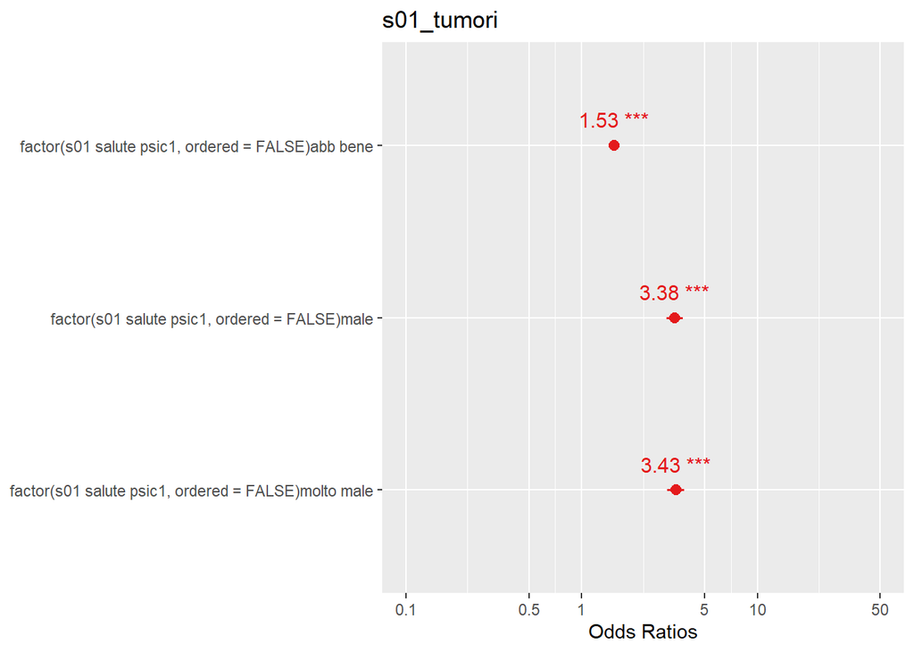

The red dots represent the estimated odds ratio for specific levels (with respect to the reference level, which is “bene”) of psychological health. All effects are significant: for example, looking at the level “Molto Male” the OR = 3.43 which means that people with very bad (perceived) psychological health have 3.43 times higher odds of having tumors.

```
##    estimate  conf.low conf.high                       facet        term
## 1 0.4911749 0.2847001 0.8473929 regione:s07_eta (Intercept) Piemonte:18
## 2 0.5111748 0.1878924 1.3906877 regione:s07_eta (Intercept) Piemonte:19
## 3 1.0861630 0.4580507 2.5755886 regione:s07_eta (Intercept) Piemonte:20
## 4 0.3968382 0.1648684 0.9551894 regione:s07_eta (Intercept) Piemonte:21
## 5 0.3185671 0.1138144 0.8916715 regione:s07_eta (Intercept) Piemonte:22
## 6 0.8023061 0.4349652 1.4798773 regione:s07_eta (Intercept) Piemonte:23
##            title reihe group p.label xpos  xmin  xmax
## 1 Random effects     1   neg            1 0.825 1.175
## 2 Random effects     2   neg            2 1.825 2.175
## 3 Random effects     3   pos            3 2.825 3.175
## 4 Random effects     4   neg            4 3.825 4.175
## 5 Random effects     5   neg            5 4.825 5.175
## 6 Random effects     6   neg            6 5.825 6.175
```

We can also model separately age and region:

| Observations | 29009 |
| --- | --- |
| Dependent variable | s01_tumori |
| Type | Mixed effects generalized linear model |
| Family | binomial |
| Link | logit |

| AIC | 35190.44 |
| --- | --- |
| BIC | 35248.36 |
| Pseudo-R² (fixed effects) | 0.04 |
| Pseudo-R² (total) | 0.26 |

| Fixed Effects | Fixed Effects Est. | Fixed Effects S.E. | Fixed Effects z val. | Fixed Effects p |
| --- | --- | --- | --- | --- |
| (Intercept) | -0.94 | 0.15 | -6.23 | 0.00 |
| factor(s01_salute_psic1, ordered = F)abb bene | 0.42 | 0.03 | 14.95 | 0.00 |
| factor(s01_salute_psic1, ordered = F)male | 1.20 | 0.05 | 22.91 | 0.00 |
| factor(s01_salute_psic1, ordered = F)molto male | 1.20 | 0.06 | 21.36 | 0.00 |

| Random Effects Group | Random Effects Parameter | Random Effects Std. Dev. |
| --- | --- | --- |
| regione:s07_eta | (Intercept) | 0.20 |
| s07_eta | (Intercept) | 0.94 |
| regione | (Intercept) | 0.30 |

| Grouping Variables Group | Grouping Variables # groups | Grouping Variables ICC |
| --- | --- | --- |
| regione:s07_eta | 982 | 0.01 |
| s07_eta | 52 | 0.21 |
| regione | 19 | 0.02 |

```
## Data: data_balanced2
## Models:
## m_disease: s01_tumori ~ (1 | regione:s07_eta) + factor(s01_salute_psic1, ordered = FALSE)
## m_disease2: s01_tumori ~ (1 | regione) + (1 | s07_eta) + (1 | regione:s07_eta) + factor(s01_salute_psic1, ordered = F)
##            npar   AIC   BIC logLik -2*log(L)  Chisq Df Pr(>Chisq)
## m_disease     5 36338 36380 -18164     36328
## m_disease2    7 35190 35248 -17588     35176 1151.8  2  < 2.2e-16 ***
## ---
## Signif. codes:  0 '***' 0.001 '**' 0.01 '*' 0.05 '.' 0.1 ' ' 1
```

[figure not shown]

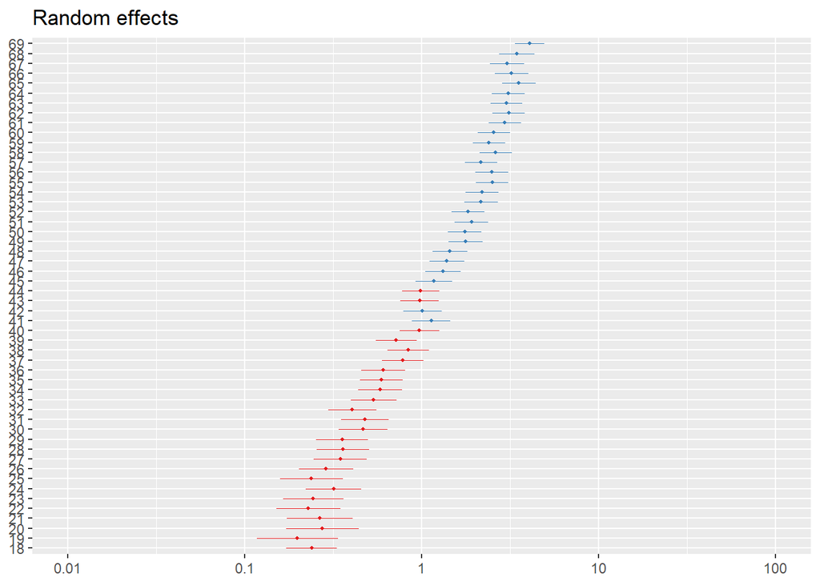

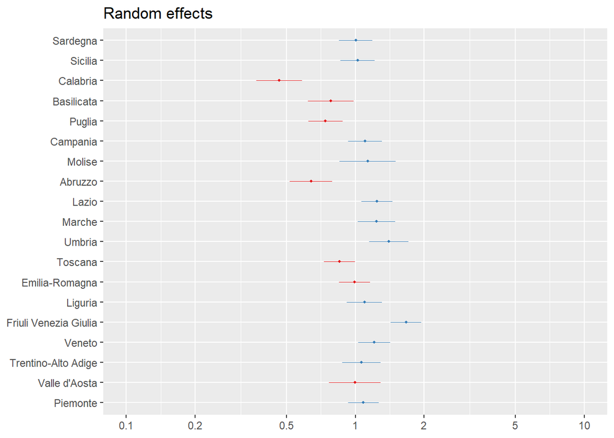

```
## [1] 2566
```

```
## [1] 595
```

In general, considering the ICC (0.24 for the new model), the interaction is better to explain the variability in the data, moreover the ANOVA test suggests that the second model is better than the first one in terms of explanation of the data.

Another try: interaction between age and wealth (s14_disp_econ):

```
## Generalized linear mixed model fit by maximum likelihood (Laplace
##   Approximation) [glmerMod]
##  Family: binomial  ( logit )
## Formula: s01_tumori ~ (1 | s14_disp_econ:s07_eta) + factor(s01_salute_psic1,
##     ordered = FALSE)
##    Data: data_balanced2
##
##       AIC       BIC    logLik -2*log(L)  df.resid
##   35804.1   35845.4  -17897.0   35794.1     29004
##
## Scaled residuals:
##     Min      1Q  Median      3Q     Max
## -2.5718 -0.8755 -0.2913  0.8238  3.9291
##
## Random effects:
##  Groups                Name        Variance Std.Dev.
##  s14_disp_econ:s07_eta (Intercept) 0.7907   0.8892
## Number of obs: 29009, groups:  s14_disp_econ:s07_eta, 208
##
## Fixed effects:
##                                                     Estimate Std. Error z value
## (Intercept)                                         -0.76417    0.06715  -11.38
## factor(s01_salute_psic1, ordered = FALSE)abb bene    0.41758    0.02773   15.06
## factor(s01_salute_psic1, ordered = FALSE)male        1.15268    0.05167   22.31
## factor(s01_salute_psic1, ordered = FALSE)molto male  1.15298    0.05545   20.79
##                                                     Pr(>|z|)
## (Intercept)                                           <2e-16 ***
## factor(s01_salute_psic1, ordered = FALSE)abb bene     <2e-16 ***
## factor(s01_salute_psic1, ordered = FALSE)male         <2e-16 ***
## factor(s01_salute_psic1, ordered = FALSE)molto male   <2e-16 ***
## ---
## Signif. codes:  0 '***' 0.001 '**' 0.01 '*' 0.05 '.' 0.1 ' ' 1
##
## Correlation of Fixed Effects:
##             (Intr) f(o=Fb f(0o=F
## f(01__1o=Fb -0.227
## f(01__1,o=F -0.131  0.289
## f(01__1o=Fm -0.129  0.269  0.153
```

| Fixed Effects | Fixed Effects Est. | Fixed Effects 2.5% | Fixed Effects 97.5% | Fixed Effects z val. | Fixed Effects p |
| --- | --- | --- | --- | --- | --- |
| (Intercept) | -0.76 | -0.90 | -0.63 | -11.38 | 0.00 |
| factor(s01_salute_psic1, ordered = FALSE)abb bene | 0.42 | 0.36 | 0.47 | 15.06 | 0.00 |
| factor(s01_salute_psic1, ordered = FALSE)male | 1.15 | 1.05 | 1.25 | 22.31 | 0.00 |
| factor(s01_salute_psic1, ordered = FALSE)molto male | 1.15 | 1.04 | 1.26 | 20.79 | 0.00 |

| Random Effects Group | Random Effects Parameter | Random Effects Std. Dev. |
| --- | --- | --- |
| s14_disp_econ:s07_eta | (Intercept) | 0.89 |

| Grouping Variables Group | Grouping Variables # groups | Grouping Variables ICC |
| --- | --- | --- |
| s14_disp_econ:s07_eta | 208 | 0.19 |

```
## # Random Effects
##
## Within-Group Variance                        3.29 (1.81)
## Between-Group Variance
##   Random Intercept (s14_disp_econ:s07_eta)   0.79 (0.89)
## N (groups per factor)
##   s14_disp_econ                                 4
##   s07_eta                                      52
## Observations                                29009
```

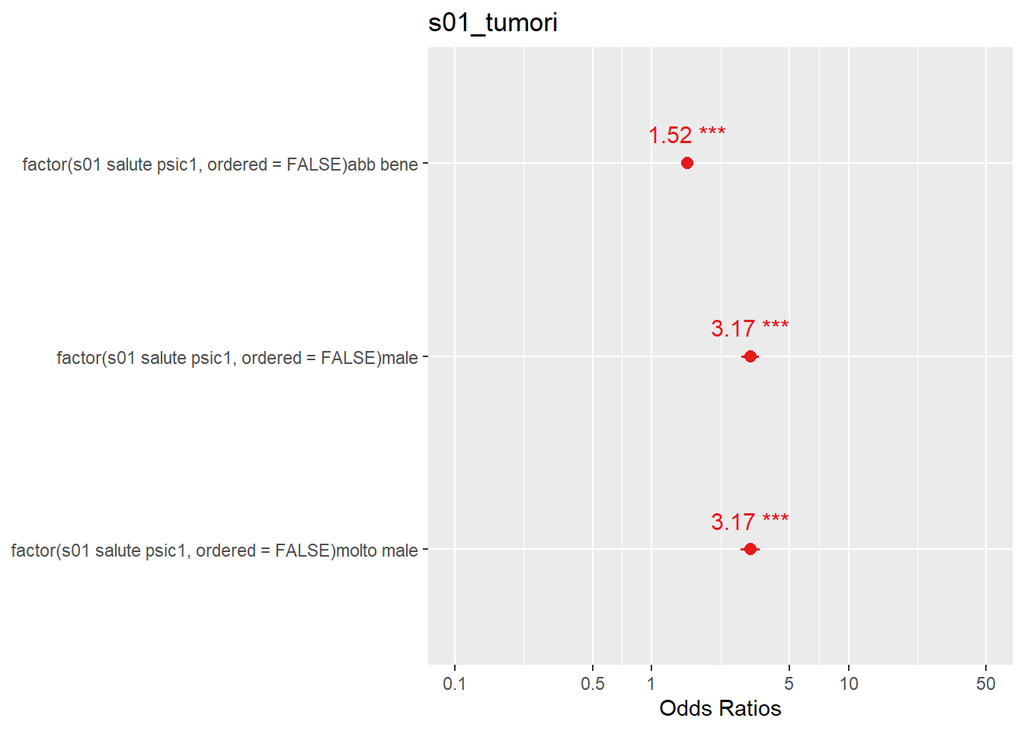

```
##    estimate   conf.low conf.high                             facet
## 1 0.3154991 0.16801500 0.5924453 s14_disp_econ:s07_eta (Intercept)
## 2 0.5688624 0.22986733 1.4077878 s14_disp_econ:s07_eta (Intercept)
## 3 0.5076124 0.23482492 1.0972870 s14_disp_econ:s07_eta (Intercept)
## 4 0.4053829 0.18922675 0.8684571 s14_disp_econ:s07_eta (Intercept)
## 5 0.2170898 0.08754764 0.5383126 s14_disp_econ:s07_eta (Intercept)
## 6 0.4369243 0.21878376 0.8725643 s14_disp_econ:s07_eta (Intercept)
##                  term          title reihe group p.label xpos  xmin  xmax
## 1 molto facilmente:18 Random effects     1   neg            1 0.825 1.175
## 2 molto facilmente:19 Random effects     2   neg            2 1.825 2.175
## 3 molto facilmente:20 Random effects     3   neg            3 2.825 3.175
## 4 molto facilmente:21 Random effects     4   neg            4 3.825 4.175
## 5 molto facilmente:22 Random effects     5   neg            5 4.825 5.175
## 6 molto facilmente:23 Random effects     6   neg            6 5.825 6.175
```

[figure not shown]

The interaction forest plot suggests that age, combined with wealth, is not strictly constant. There’s a logarithmic pattern in this data, and variability is pretty higher for higher levels of age.

We can also model separately age and wealth:

| Observations | 29009 |
| --- | --- |
| Dependent variable | s01_tumori |
| Type | Mixed effects generalized linear model |
| Family | binomial |
| Link | logit |

| AIC | 35535.73 |
| --- | --- |
| BIC | 35593.65 |
| Pseudo-R² (fixed effects) | 0.03 |
| Pseudo-R² (total) | 0.24 |

| Fixed Effects | Fixed Effects Est. | Fixed Effects S.E. | Fixed Effects z val. | Fixed Effects p |
| --- | --- | --- | --- | --- |
| (Intercept) | -0.83 | 0.13 | -6.18 | 0.00 |
| factor(s01_salute_psic1, ordered = F)abb bene | 0.42 | 0.03 | 15.07 | 0.00 |
| factor(s01_salute_psic1, ordered = F)male | 1.15 | 0.05 | 22.27 | 0.00 |
| factor(s01_salute_psic1, ordered = F)molto male | 1.16 | 0.06 | 20.90 | 0.00 |

| Random Effects Group | Random Effects Parameter | Random Effects Std. Dev. |
| --- | --- | --- |
| s14_disp_econ:s07_eta | (Intercept) | 0.14 |
| s07_eta | (Intercept) | 0.92 |
| s14_disp_econ | (Intercept) | 0.06 |

| Grouping Variables Group | Grouping Variables # groups | Grouping Variables ICC |
| --- | --- | --- |
| s14_disp_econ:s07_eta | 208 | 0.00 |
| s07_eta | 52 | 0.20 |
| s14_disp_econ | 4 | 0.00 |

```
## Data: data_balanced2
## Models:
## m_disease_disp: s01_tumori ~ (1 | s14_disp_econ:s07_eta) + factor(s01_salute_psic1, ordered = FALSE)
## m_disease_disp2: s01_tumori ~ (1 | s14_disp_econ) + (1 | s07_eta) + (1 | s14_disp_econ:s07_eta) + factor(s01_salute_psic1, ordered = F)
##                 npar   AIC   BIC logLik -2*log(L)  Chisq Df Pr(>Chisq)
## m_disease_disp     5 35804 35845 -17897     35794
## m_disease_disp2    7 35536 35594 -17761     35522 272.34  2  < 2.2e-16 ***
## ---
## Signif. codes:  0 '***' 0.001 '**' 0.01 '*' 0.05 '.' 0.1 ' ' 1
```

We can also plot the forest plot for the random effects:

[figure not shown]

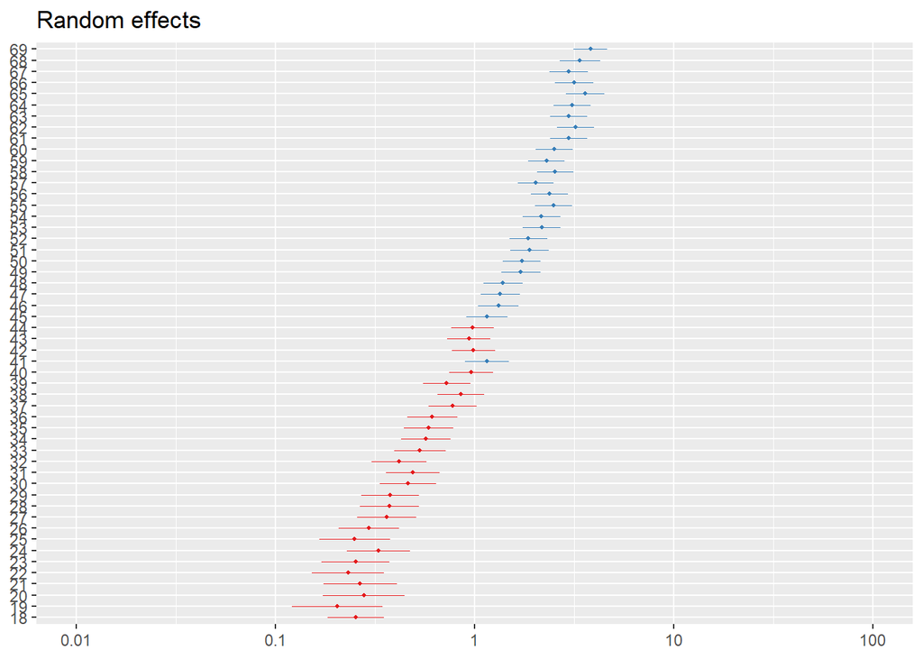

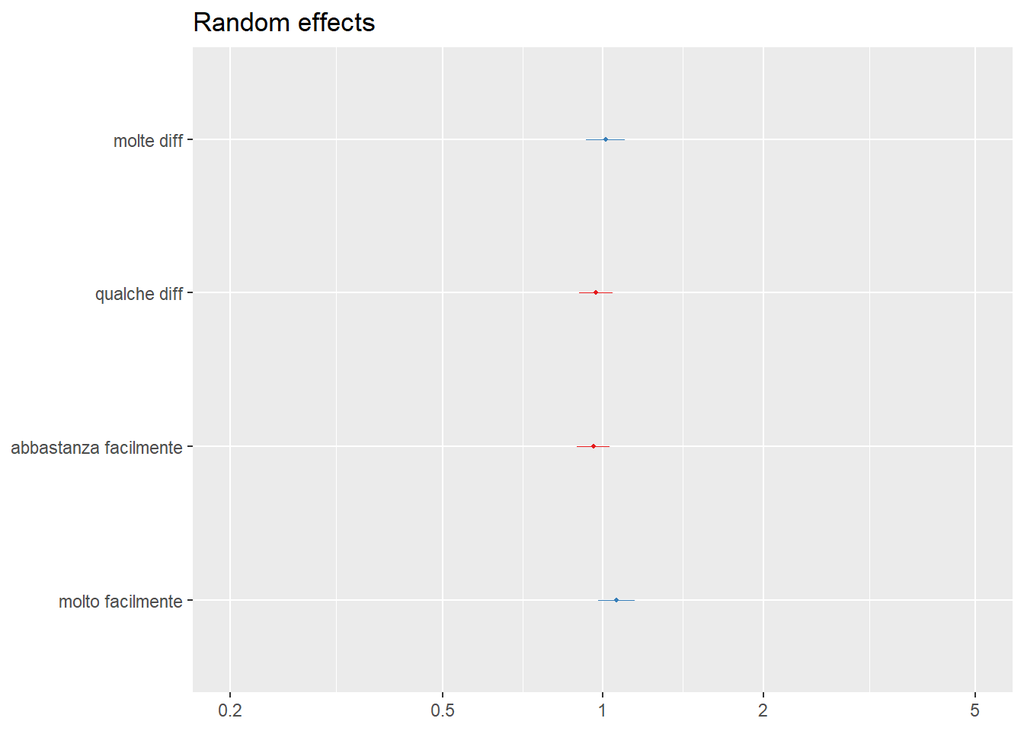

It is clear that, looking at variable age, there’s an increase in positive and significant effects, with respect to the mean. On the other hand, wealth seems to be less significant (estimates close to 1).

**Psychological health as response variable**

Now, we want to investigate the reverse problem: is psychological health related to which variable?

The aim is to fit an ordinal regression to predict psychological health (s01_salute_psic1) based on tumor status and economic availability; this model estimates the cumulative probability that an observation belongs to a category which is less / equal to k.

```
##
## Call:
## vglm(formula = s01_salute_psic1 ~ s01_tumori + s14_disp_econ,
##     family = cumulative(parallel = TRUE), data = data_balanced2)
##
## Coefficients:
##                                     Estimate Std. Error z value Pr(>|z|)
## (Intercept):1                      -0.004547   0.035144  -0.129   0.8970
## (Intercept):2                       2.181225   0.037869  57.599  < 2e-16 ***
## (Intercept):3                       3.074374   0.041401  74.259  < 2e-16 ***
## s01_tumorisì                       -0.661692   0.022533 -29.365  < 2e-16 ***
## s14_disp_econabbastanza facilmente  0.078707   0.036682   2.146   0.0319 *
## s14_disp_econqualche diff          -0.270495   0.038524  -7.021  2.2e-12 ***
## s14_disp_econmolte diff            -0.705555   0.055462 -12.721  < 2e-16 ***
## ---
## Signif. codes:  0 '***' 0.001 '**' 0.01 '*' 0.05 '.' 0.1 ' ' 1
##
## Names of linear predictors: logitlink(P[Y<=1]), logitlink(P[Y<=2]),
## logitlink(P[Y<=3])
##
## Residual deviance: 63550.55 on 87020 degrees of freedom
##
## Log-likelihood: -31775.28 on 87020 degrees of freedom
##
## Number of Fisher scoring iterations: 5
##
## No Hauck-Donner effect found in any of the estimates
##
##
## Exponentiated coefficients:
##                       s01_tumorisì s14_disp_econabbastanza facilmente
##                          0.5159777                          1.0818874
##          s14_disp_econqualche diff            s14_disp_econmolte diff
##                          0.7630021                          0.4938346
```

The intercepts indicate the thresholds between one category and the next one.

In this case, for example, looking at the variable tumors (with “no” as the reference level), we see that its associated coefficient is -0.66. This means that having a tumor is associated with a higher probability of reporting worse psychological health (i.e., being in higher categories of the outcome variable).

Individuals with tumors and those experiencing greater economic difficulties are significantly more likely to report worse psychological health. The effect is strongest for those with many financial difficulties. The model assumes proportional odds and shows statistically robust results.

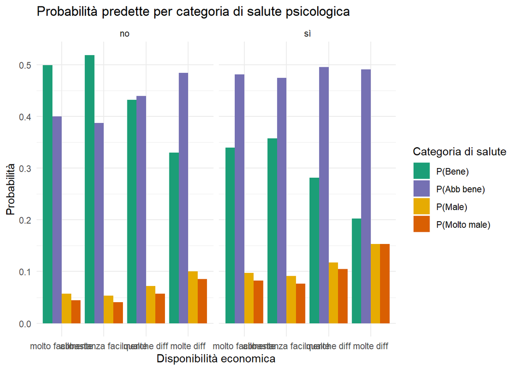

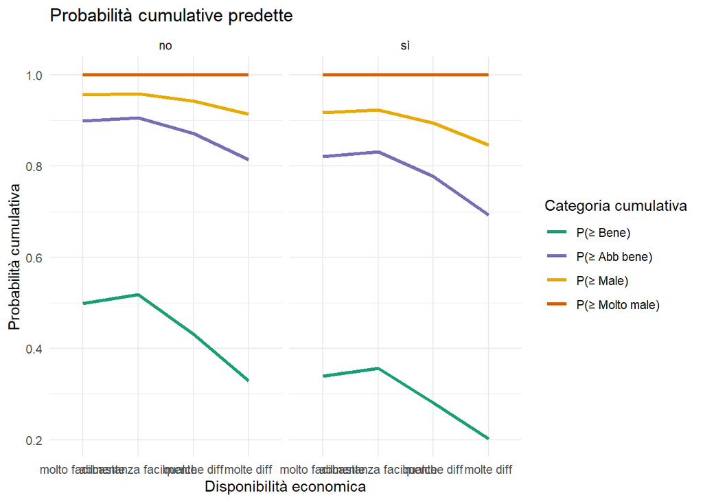

Comparison with the null model:

```
## [1] 8.719874e-273
```

Based on the Likelihood Ratio Test, it’s clear that the complex model is better than the null one.

Now we are going to add citizenship as third variable:

```
##
## Call:
## vglm(formula = s01_salute_psic1 ~ s01_tumori + s14_cittadin +
##     s14_disp_econ, family = cumulative(parallel = TRUE), data = data_balanced2)
##
## Coefficients:
##                                     Estimate Std. Error z value Pr(>|z|)
## (Intercept):1                      -0.009568   0.035203  -0.272  0.78578
## (Intercept):2                       2.177627   0.037918  57.429  < 2e-16 ***
## (Intercept):3                       3.071065   0.041447  74.097  < 2e-16 ***
## s01_tumorisì                       -0.655106   0.022583 -29.009  < 2e-16 ***
## s14_cittadinstraniera               0.223395   0.054264   4.117 3.84e-05 ***
## s14_cittadindoppia                 -0.227335   0.087759  -2.590  0.00959 **
## s14_disp_econabbastanza facilmente  0.077418   0.036697   2.110  0.03489 *
## s14_disp_econqualche diff          -0.281761   0.038647  -7.291 3.08e-13 ***
## s14_disp_econmolte diff            -0.720305   0.055581 -12.960  < 2e-16 ***
## ---
## Signif. codes:  0 '***' 0.001 '**' 0.01 '*' 0.05 '.' 0.1 ' ' 1
##
## Names of linear predictors: logitlink(P[Y<=1]), logitlink(P[Y<=2]),
## logitlink(P[Y<=3])
##
## Residual deviance: 63526.03 on 87018 degrees of freedom
##
## Log-likelihood: -31763.02 on 87018 degrees of freedom
##
## Number of Fisher scoring iterations: 5
##
## No Hauck-Donner effect found in any of the estimates
##
##
## Exponentiated coefficients:
##                       s01_tumorisì              s14_cittadinstraniera
##                          0.5193868                          1.2503138
##                 s14_cittadindoppia s14_disp_econabbastanza facilmente
##                          0.7966542                          1.0804936
##          s14_disp_econqualche diff            s14_disp_econmolte diff
##                          0.7544542                          0.4866036
```

```
## [1] 4.735398e-06
```

Also for this case, the model with the added variable seems more descriptive than the simpler one.

# Conclusion

The results of our analyses indicate that the applied models are statistically significant and support the existence of a bidirectional association between mental and psychological health; it’s also interesting see how perceived well-being is a focal point in this analysis.

These findings underscore the importance of integrated approaches in both the prevention and treatment of oncological diseases, suggesting that psychological well-being should be considered a key component in comprehensive healthcare strategies. Additionally, public health policies should aim to incorporate psychological screening and support as part of routine oncological care, especially for socioeconomically vulnerable populations.